# main

```python
# import necessary modules
import numpy as np
import pandas as pd
import seaborn as sns
import matplotlib.pyplot as plt
import os
import warnings
#from datetime import datetime
from scipy import stats
from scipy.stats import norm, skew, probplot

warnings.filterwarnings('ignore')
```

#### 1. Data Importation

```python
dftrain = pd.read_csv('../input/covid19-global-forecasting-week-4/train.csv', parse_dates=['Date']).sort_values(by=['Country_Region', 'Date'])
dftest = pd.read_csv('../input/covid19-global-forecasting-week-4/test.csv', parse_dates=['Date']).sort_values(by=['Country_Region', 'Date'])
dftrain.head()
```

|  | Id | Province_State | Country_Region | Date | ConfirmedCases | Fatalities |
| --- | --- | --- | --- | --- | --- | --- |
| 0 | 1 | NaN | Afghanistan | 2020-01-22 | 0.0 | 0.0 |
| 1 | 2 | NaN | Afghanistan | 2020-01-23 | 0.0 | 0.0 |
| 2 | 3 | NaN | Afghanistan | 2020-01-24 | 0.0 | 0.0 |
| 3 | 4 | NaN | Afghanistan | 2020-01-25 | 0.0 | 0.0 |
| 4 | 5 | NaN | Afghanistan | 2020-01-26 | 0.0 | 0.0 |

```python
confirmed = pd.read_csv('https://raw.githubusercontent.com/CSSEGISandData/COVID-19/master/csse_covid_19_data/csse_covid_19_time_series/time_series_covid19_confirmed_global.csv').sort_values(by='Country/Region')#.set_index('Country/Region')
deaths = pd.read_csv('https://raw.githubusercontent.com/CSSEGISandData/COVID-19/master/csse_covid_19_data/csse_covid_19_time_series/time_series_covid19_deaths_global.csv')#.set_index('Country/Region')
recovered = pd.read_csv('https://raw.githubusercontent.com/CSSEGISandData/COVID-19/master/csse_covid_19_data/csse_covid_19_time_series/time_series_covid19_recovered_global.csv')#.set_index('Country/Region')
```

```python
recovered.head()
```

|  | Province/State | Country/Region | Lat | Long | 1/22/20 | 1/23/20 | 1/24/20 | 1/25/20 | 1/26/20 | 1/27/20 | ... | 4/11/20 | 4/12/20 | 4/13/20 | 4/14/20 | 4/15/20 | 4/16/20 | 4/17/20 | 4/18/20 | 4/19/20 | 4/20/20 |
| --- | --- | --- | --- | --- | --- | --- | --- | --- | --- | --- | --- | --- | --- | --- | --- | --- | --- | --- | --- | --- | --- |
| 0 | NaN | Afghanistan | 33.0000 | 65.0000 | 0 | 0 | 0 | 0 | 0 | 0 | ... | 32 | 32 | 32 | 40 | 43 | 54 | 99 | 112 | 131 | 135 |
| 1 | NaN | Albania | 41.1533 | 20.1683 | 0 | 0 | 0 | 0 | 0 | 0 | ... | 197 | 217 | 232 | 248 | 251 | 277 | 283 | 302 | 314 | 327 |
| 2 | NaN | Algeria | 28.0339 | 1.6596 | 0 | 0 | 0 | 0 | 0 | 0 | ... | 460 | 591 | 601 | 691 | 708 | 783 | 846 | 894 | 1047 | 1099 |
| 3 | NaN | Andorra | 42.5063 | 1.5218 | 0 | 0 | 0 | 0 | 0 | 0 | ... | 71 | 128 | 128 | 128 | 169 | 169 | 191 | 205 | 235 | 248 |
| 4 | NaN | Angola | -11.2027 | 17.8739 | 0 | 0 | 0 | 0 | 0 | 0 | ... | 4 | 4 | 4 | 5 | 5 | 5 | 5 | 6 | 6 | 6 |

5 rows × 94 columns

```python
confirmed['Country_Region'] = confirmed['Country/Region']
confirmed['Province_State'] = confirmed['Province/State']
confirmed.head()
```

|  | Province/State | Country/Region | Lat | Long | 1/22/20 | 1/23/20 | 1/24/20 | 1/25/20 | 1/26/20 | 1/27/20 | ... | 4/13/20 | 4/14/20 | 4/15/20 | 4/16/20 | 4/17/20 | 4/18/20 | 4/19/20 | 4/20/20 | Country_Region | Province_State |
| --- | --- | --- | --- | --- | --- | --- | --- | --- | --- | --- | --- | --- | --- | --- | --- | --- | --- | --- | --- | --- | --- |
| 0 | NaN | Afghanistan | 33.0000 | 65.0000 | 0 | 0 | 0 | 0 | 0 | 0 | ... | 665 | 714 | 784 | 840 | 906 | 933 | 996 | 1026 | Afghanistan | NaN |
| 1 | NaN | Albania | 41.1533 | 20.1683 | 0 | 0 | 0 | 0 | 0 | 0 | ... | 467 | 475 | 494 | 518 | 539 | 548 | 562 | 584 | Albania | NaN |
| 2 | NaN | Algeria | 28.0339 | 1.6596 | 0 | 0 | 0 | 0 | 0 | 0 | ... | 1983 | 2070 | 2160 | 2268 | 2418 | 2534 | 2629 | 2718 | Algeria | NaN |
| 3 | NaN | Andorra | 42.5063 | 1.5218 | 0 | 0 | 0 | 0 | 0 | 0 | ... | 646 | 659 | 673 | 673 | 696 | 704 | 713 | 717 | Andorra | NaN |
| 4 | NaN | Angola | -11.2027 | 17.8739 | 0 | 0 | 0 | 0 | 0 | 0 | ... | 19 | 19 | 19 | 19 | 19 | 24 | 24 | 24 | Angola | NaN |

5 rows × 96 columns

Transpose the dataframes

```python
def transpose_df(df):
    df = df.drop(['Lat','Long'],axis=1).groupby('Country/Region').sum().T
    df.index = pd.to_datetime(df.index)#.date
    return df
```

```python
confirmedT = transpose_df(confirmed)
deathsT = transpose_df(deaths)
recoveredT = transpose_df(recovered)
mortalityT = deathsT/confirmedT
```

```python
confirmed.head()
```

|  | Province/State | Country/Region | Lat | Long | 1/22/20 | 1/23/20 | 1/24/20 | 1/25/20 | 1/26/20 | 1/27/20 | ... | 4/13/20 | 4/14/20 | 4/15/20 | 4/16/20 | 4/17/20 | 4/18/20 | 4/19/20 | 4/20/20 | Country_Region | Province_State |
| --- | --- | --- | --- | --- | --- | --- | --- | --- | --- | --- | --- | --- | --- | --- | --- | --- | --- | --- | --- | --- | --- |
| 0 | NaN | Afghanistan | 33.0000 | 65.0000 | 0 | 0 | 0 | 0 | 0 | 0 | ... | 665 | 714 | 784 | 840 | 906 | 933 | 996 | 1026 | Afghanistan | NaN |
| 1 | NaN | Albania | 41.1533 | 20.1683 | 0 | 0 | 0 | 0 | 0 | 0 | ... | 467 | 475 | 494 | 518 | 539 | 548 | 562 | 584 | Albania | NaN |
| 2 | NaN | Algeria | 28.0339 | 1.6596 | 0 | 0 | 0 | 0 | 0 | 0 | ... | 1983 | 2070 | 2160 | 2268 | 2418 | 2534 | 2629 | 2718 | Algeria | NaN |
| 3 | NaN | Andorra | 42.5063 | 1.5218 | 0 | 0 | 0 | 0 | 0 | 0 | ... | 646 | 659 | 673 | 673 | 696 | 704 | 713 | 717 | Andorra | NaN |
| 4 | NaN | Angola | -11.2027 | 17.8739 | 0 | 0 | 0 | 0 | 0 | 0 | ... | 19 | 19 | 19 | 19 | 19 | 24 | 24 | 24 | Angola | NaN |

5 rows × 96 columns

```python
dftrain = dftrain.join(confirmed[['Country_Region', 'Province_State', 'Lat', 'Long']].set_index(['Province_State', 'Country_Region']), on=['Province_State', 'Country_Region'])#
```

```python
dftrain.head()
```

|  | Id | Province_State | Country_Region | Date | ConfirmedCases | Fatalities | Lat | Long |
| --- | --- | --- | --- | --- | --- | --- | --- | --- |
| 0 | 1 | NaN | Afghanistan | 2020-01-22 | 0.0 | 0.0 | 33.0 | 65.0 |
| 1 | 2 | NaN | Afghanistan | 2020-01-23 | 0.0 | 0.0 | 33.0 | 65.0 |
| 2 | 3 | NaN | Afghanistan | 2020-01-24 | 0.0 | 0.0 | 33.0 | 65.0 |
| 3 | 4 | NaN | Afghanistan | 2020-01-25 | 0.0 | 0.0 | 33.0 | 65.0 |
| 4 | 5 | NaN | Afghanistan | 2020-01-26 | 0.0 | 0.0 | 33.0 | 65.0 |

```python
def add_day(df):
    df['Date'] = df.index
    df['Dayofyear'] = df['Date'].dt.dayofyear
    return df
```

```python
dftrain['Dayofyear'] = dftrain['Date'].dt.dayofyear
dftest['Dayofyear'] = dftest['Date'].dt.dayofyear
```

```python
allcountries = dftrain['Country_Region'].unique().tolist()
```

Compute the distance between all countries from the Haversine formula using their latitude and longitude.

```python
from math import radians, cos, sin, asin, sqrt

def haversine(lat1, lon1, lat2, lon2):
    """
    Calculate the great circle distance between two points
    on the earth (specified in decimal degrees)
    """
    # convert decimal degrees to radians
    lon1, lat1, lon2, lat2 = map(radians, [lon1, lat1, lon2, lat2])

    # haversine formula
    dlon = lon2 - lon1
    dlat = lat2 - lat1
    a = sin(dlat/2)**2 + cos(lat1) * cos(lat2) * sin(dlon/2)**2
    c = 2 * asin(sqrt(a))
    r = 6371 # Radius of earth in kilometers. Use 3956 for miles
    return c * r
```

```python
list_countries = dftrain[dftrain['Date'] == '2020-01-22']['Country_Region'].tolist()
list_states = dftrain[dftrain['Date'] == '2020-01-22']['Province_State'].tolist()
#
df_distance = pd.DataFrame(index=[list_countries, list_states],columns=[list_countries, list_states])
df_distance.index.names = ['Country_Region', 'Province_State']
df_distance.columns.names = ['Country_Region', 'Province_State']
df_distance['Lat'] = dftrain[dftrain['Date'] == '2020-01-22']['Lat'].tolist()
df_distance['Long']  = dftrain[dftrain['Date'] == '2020-01-22']['Long'].tolist()
#
for country, state in list(zip(list_countries, list_states)):
    lat, lon = df_distance.loc[(country, state),['Lat', 'Long']]
    df_distance[(country, state)] = df_distance[['Lat', 'Long']].apply(lambda x: haversine(lat, lon, x[0], x[1]), axis=1)
#
df_distance.head()
```

| Country_Region | Country_Region Province_State | Afghanistan NaN | Albania NaN | Algeria NaN | Andorra NaN | Angola NaN | Antigua and Barbuda NaN | Argentina NaN | Armenia NaN | Australia Australian Capital Territory | Australia New South Wales | ... | Uruguay NaN | Uzbekistan NaN | Venezuela NaN | Vietnam NaN | West Bank and Gaza NaN | Western Sahara NaN | Zambia NaN | Zimbabwe NaN | Lat | Long |
| --- | --- | --- | --- | --- | --- | --- | --- | --- | --- | --- | --- | --- | --- | --- | --- | --- | --- | --- | --- | --- | --- | --- |
| Afghanistan | NaN | 0.000000 | 4032.954071 | 6001.829809 | 5549.003559 | 7005.675452 | 12085.762473 | 15396.415945 | 1943.325980 | 11583.324743 | 11666.674774 | ... | 14553.762823 | 932.256034 | 13286.686038 | 4702.637691 | 2785.426888 | 7497.184006 | 6647.360572 | 6967.328629 | 33.0000 | 65.0000 |
| Albania | NaN | 4032.954071 | 0.000000 | 2227.062426 | 1549.100043 | 5826.484492 | 8108.453022 | 12251.924000 | 2095.659770 | 15571.755226 | 15679.423369 | ... | 11287.189036 | 3670.794017 | 9267.216505 | 8667.583167 | 1686.271119 | 3588.952646 | 6345.624430 | 6875.274553 | 41.1533 | 20.1683 |
| Algeria | NaN | 6001.829809 | 2227.062426 | 0.000000 | 1609.305432 | 4699.099959 | 6560.907727 | 10025.301159 | 4168.276650 | 16835.303396 | 17051.273179 | ... | 9061.059324 | 5810.635084 | 7540.535697 | 10704.425063 | 3249.502965 | 1511.764885 | 5618.096430 | 6149.101332 | 28.0339 | 1.6596 |
| Andorra | NaN | 5549.003559 | 1549.100043 | 1609.305432 | 0.000000 | 6200.429344 | 6563.046533 | 11141.163935 | 3605.996200 | 17118.308524 | 17215.170810 | ... | 10181.759769 | 5092.236126 | 7738.295866 | 10101.629210 | 3181.291453 | 2426.703660 | 6998.511724 | 7539.103654 | 42.5063 | 1.5218 |
| Angola | NaN | 7005.675452 | 5826.484492 | 4699.099959 | 6200.429344 | 0.000000 | 9297.902971 | 8499.833702 | 6351.869043 | 12718.664284 | 12986.232923 | ... | 7814.736998 | 7549.731184 | 9546.459238 | 10362.121417 | 5142.024726 | 5164.129798 | 1219.609284 | 1624.477661 | -11.2027 | 17.8739 |

5 rows × 315 columns

Create dataframe listing the starting date of lockdowns

```python
from datetime import datetime
lockdown = confirmedT.copy()
lockdown.loc[:,:] = 0
country_lockdown = pd.DataFrame({
                    'Argentina' : datetime(2020,3,19), # 2020-03-19
                    'Australia' : datetime(2020,3,23), # 2020-03-23
                    'Austria' : datetime(2020,3,16), # 2020-03-16
                    'Belgium' : datetime(2020,3,18), # 2020-03-18
                    'Colombia' : datetime(2020,3,25), # 2020-03-25
                    'Czechia' : datetime(2020,3,16), # 2020-03-16
                    'Denmark' : datetime(2020,3,11), # 2020-03-11
                    'El Salvador' : datetime(2020,3,12), # 2020-03-12
                    'Fiji' : datetime(2020,3,9), # 2020-03-20
                    'France' : datetime(2020,3,17), # 2020-03-17
                    'Greece' : datetime(2020,3,23), # 2020-03-23
                    'Honduras' : datetime(2020,3,17), # 2020-03-17
                    'Ireland' : datetime(2020,3,12), # 2020-03-12
                    'Italy' : datetime(2020,3,9), # 2020-03-09
                    'Lebanon' : datetime(2020,3,15), # 2020-03-15
                    'Lithuania' : datetime(2020,3,16), # 2020-03-16
                    'Malaysia' : datetime(2020,3,18), # 2020-03-18
                    'Morocco' : datetime(2020,3,19), # 2020-03-19
                    'Philippines' : datetime(2020,3,15), # 2020-03-15
                    'Poland' : datetime(2020,3,13), # 2020-03-13
                    'Romania' : datetime(2020,3,25), # 2020-03-25
                    'South Africa' : datetime(2020,3,26), # 2020-03-26
                    'Spain' : datetime(2020,3,14), # 2020-03-14
                    'Tunisia' : datetime(2020,3,22), # 2020-03-22
                    'United Kingdom' : datetime(2020,3,23), # 2020-03-23
                    'Venezuela' : datetime(2020,3,17), # 2020-03-17}
                    },index=['Start Lockdown Country']).T
state_lockdown = pd.DataFrame({
                    ('US', 'California') : datetime(2020,3,19), # 2020-03-19
                    ('US', 'Nevada') : datetime(2020,3,20), # 2020-03-20
                    ('US', 'Connecticut') : datetime(2020,3,23), # 2020-03-23
                    ('US', 'Illinois') : datetime(2020,3,21), # 2020-03-21
                    ('US', 'Massachusetts') : datetime(2020,3,24), # 2020-03-24
                    ('US', 'Michigan') : datetime(2020,3,24), # 2020-03-24
                    ('US', 'New York') : datetime(2020,3,20), # 2020-03-20
                    ('US', 'Oregon') : datetime(2020,3,24), # 2020-03-24
                   },index=['Start Lockdown State']).T
state_lockdown.head()
```

|  |  | Start Lockdown State |
| --- | --- | --- |
| US | California | 2020-03-19 |
|  | Nevada | 2020-03-20 |
|  | Connecticut | 2020-03-23 |
|  | Illinois | 2020-03-21 |
|  | Massachusetts | 2020-03-24 |

```python
country_lockdown
```

|  | Start Lockdown Country |
| --- | --- |
| Argentina | 2020-03-19 |
| Australia | 2020-03-23 |
| Austria | 2020-03-16 |
| Belgium | 2020-03-18 |
| Colombia | 2020-03-25 |
| Czechia | 2020-03-16 |
| Denmark | 2020-03-11 |
| El Salvador | 2020-03-12 |
| Fiji | 2020-03-09 |
| France | 2020-03-17 |
| Greece | 2020-03-23 |
| Honduras | 2020-03-17 |
| Ireland | 2020-03-12 |
| Italy | 2020-03-09 |
| Lebanon | 2020-03-15 |
| Lithuania | 2020-03-16 |
| Malaysia | 2020-03-18 |
| Morocco | 2020-03-19 |
| Philippines | 2020-03-15 |
| Poland | 2020-03-13 |
| Romania | 2020-03-25 |
| South Africa | 2020-03-26 |
| Spain | 2020-03-14 |
| Tunisia | 2020-03-22 |
| United Kingdom | 2020-03-23 |
| Venezuela | 2020-03-17 |

```python
 dftrainlockdown = dftrain.join(country_lockdown, on='Country_Region').join(state_lockdown, on=['Country_Region', 'Province_State'])
# dftrainlockdown['Lockdown'] = 0
# dftrainlockdown.loc[dftrainlockdown['Date'] > dftrainlockdown['Start Lockdown Country'],'Lockdown'] = 1
# dftrainlockdown.loc[dftrainlockdown['Date'] > dftrainlockdown['Start Lockdown State'],'Lockdown'] = 1
```

```python
dftrainlockdown.head()
```

|  | Id | Province_State | Country_Region | Date | ConfirmedCases | Fatalities | Lat | Long | Dayofyear | Start Lockdown Country | Start Lockdown State |
| --- | --- | --- | --- | --- | --- | --- | --- | --- | --- | --- | --- |
| 0 | 1 | NaN | Afghanistan | 2020-01-22 | 0.0 | 0.0 | 33.0 | 65.0 | 22 | NaT | NaT |
| 1 | 2 | NaN | Afghanistan | 2020-01-23 | 0.0 | 0.0 | 33.0 | 65.0 | 23 | NaT | NaT |
| 2 | 3 | NaN | Afghanistan | 2020-01-24 | 0.0 | 0.0 | 33.0 | 65.0 | 24 | NaT | NaT |
| 3 | 4 | NaN | Afghanistan | 2020-01-25 | 0.0 | 0.0 | 33.0 | 65.0 | 25 | NaT | NaT |
| 4 | 5 | NaN | Afghanistan | 2020-01-26 | 0.0 | 0.0 | 33.0 | 65.0 | 26 | NaT | NaT |

```python
dftrain.head()
```

|  | Id | Province_State | Country_Region | Date | ConfirmedCases | Fatalities | Lat | Long | Dayofyear |
| --- | --- | --- | --- | --- | --- | --- | --- | --- | --- |
| 0 | 1 | NaN | Afghanistan | 2020-01-22 | 0.0 | 0.0 | 33.0 | 65.0 | 22 |
| 1 | 2 | NaN | Afghanistan | 2020-01-23 | 0.0 | 0.0 | 33.0 | 65.0 | 23 |
| 2 | 3 | NaN | Afghanistan | 2020-01-24 | 0.0 | 0.0 | 33.0 | 65.0 | 24 |
| 3 | 4 | NaN | Afghanistan | 2020-01-25 | 0.0 | 0.0 | 33.0 | 65.0 | 25 |
| 4 | 5 | NaN | Afghanistan | 2020-01-26 | 0.0 | 0.0 | 33.0 | 65.0 | 26 |

```python
dftrainlockdown = dftrain.join(country_lockdown, on='Country_Region').join(state_lockdown, on=['Country_Region', 'Province_State'])
```

```python
dftrainlockdown.head()
```

|  | Id | Province_State | Country_Region | Date | ConfirmedCases | Fatalities | Lat | Long | Dayofyear | Start Lockdown Country | Start Lockdown State |
| --- | --- | --- | --- | --- | --- | --- | --- | --- | --- | --- | --- |
| 0 | 1 | NaN | Afghanistan | 2020-01-22 | 0.0 | 0.0 | 33.0 | 65.0 | 22 | NaT | NaT |
| 1 | 2 | NaN | Afghanistan | 2020-01-23 | 0.0 | 0.0 | 33.0 | 65.0 | 23 | NaT | NaT |
| 2 | 3 | NaN | Afghanistan | 2020-01-24 | 0.0 | 0.0 | 33.0 | 65.0 | 24 | NaT | NaT |
| 3 | 4 | NaN | Afghanistan | 2020-01-25 | 0.0 | 0.0 | 33.0 | 65.0 | 25 | NaT | NaT |
| 4 | 5 | NaN | Afghanistan | 2020-01-26 | 0.0 | 0.0 | 33.0 | 65.0 | 26 | NaT | NaT |

Create lockdown flag

```python
dftrainlockdown.loc[dftrainlockdown['Date'] > dftrainlockdown['Start Lockdown Country'],'Lockdown'] = 1
dftrainlockdown.loc[dftrainlockdown['Date'] > dftrainlockdown['Start Lockdown State'],'Lockdown'] = 1
```

```python
dftrainlockdown.head()
```

|  | Id | Province_State | Country_Region | Date | ConfirmedCases | Fatalities | Lat | Long | Dayofyear | Start Lockdown Country | Start Lockdown State | Lockdown |
| --- | --- | --- | --- | --- | --- | --- | --- | --- | --- | --- | --- | --- |
| 0 | 1 | NaN | Afghanistan | 2020-01-22 | 0.0 | 0.0 | 33.0 | 65.0 | 22 | NaT | NaT | NaN |
| 1 | 2 | NaN | Afghanistan | 2020-01-23 | 0.0 | 0.0 | 33.0 | 65.0 | 23 | NaT | NaT | NaN |
| 2 | 3 | NaN | Afghanistan | 2020-01-24 | 0.0 | 0.0 | 33.0 | 65.0 | 24 | NaT | NaT | NaN |
| 3 | 4 | NaN | Afghanistan | 2020-01-25 | 0.0 | 0.0 | 33.0 | 65.0 | 25 | NaT | NaT | NaN |
| 4 | 5 | NaN | Afghanistan | 2020-01-26 | 0.0 | 0.0 | 33.0 | 65.0 | 26 | NaT | NaT | NaN |

Read csv file giving some useful information for all countries

```python
pop = pd.read_csv('../input/population_by_country_2020.csv').set_index('Country (or dependency)')
pop.sort_values(by='Country (or dependency)').head()
```

| Country (or dependency) | Population (2020) | Yearly Change | Net Change | Density (P/Km²) | Land Area (Km²) | Migrants (net) | Fert. Rate | Med. Age | Urban Pop % | World Share |
| --- | --- | --- | --- | --- | --- | --- | --- | --- | --- | --- |
| Afghanistan | 38928346 | 2.33% | 886592 | 60 | 652860 | -62920.0 | 4.6 | 18 | 25% | 0.50% |
| Albania | 2877797 | -0.11% | -3120 | 105 | 27400 | -14000.0 | 1.6 | 36 | 63% | 0.04% |
| Algeria | 43851044 | 1.85% | 797990 | 18 | 2381740 | -10000.0 | 3.1 | 29 | 73% | 0.56% |
| American Samoa | 55191 | -0.22% | -121 | 276 | 200 | NaN | N.A. | N.A. | 88% | 0.00% |
| Andorra | 77265 | 0.16% | 123 | 164 | 470 | NaN | N.A. | N.A. | 88% | 0.00% |

```python
flights = pd.read_csv('../input/airtraffic.csv')
```

Join all dataframes.

```python
dftrainall = dftrain.join(pop, on='Country_Region')
```

```python
dftrainall['Lockdown'] = dftrainlockdown['Lockdown']
```

```python
#dftrainall = dftrainall.join(flights, on='Country_Region')
dftrainall = pd.merge(dftrainall, flights, how='left', on=['Country_Region'])
```

```python
dftrainall['Mortality'] = dftrainall['Fatalities']/dftrainall['ConfirmedCases']
dftrainall['ConfirmedCases_by_pop'] = dftrainall['ConfirmedCases']/dftrainall['Population (2020)']
dftrainall['ConfirmedCases_by_Km²'] = dftrainall['ConfirmedCases']/dftrainall['Land Area (Km²)']
```

```python
dftrainall.tail()
```

|  | Id | Province_State | Country_Region | Date | ConfirmedCases | Fatalities | Lat | Long | Dayofyear | Population (2020) | ... | Migrants (net) | Fert. Rate | Med. Age | Urban Pop % | World Share | Lockdown | FlightPassengers_2018 | Mortality | ConfirmedCases_by_pop | ConfirmedCases_by_Km² |
| --- | --- | --- | --- | --- | --- | --- | --- | --- | --- | --- | --- | --- | --- | --- | --- | --- | --- | --- | --- | --- | --- |
| 25661 | 35646 | NaN | Zimbabwe | 2020-04-08 | 11.0 | 3.0 | -20.0 | 30.0 | 99 | 14862924.0 | ... | -116858.0 | 3.6 | 19 | 38% | 0.19% | NaN | 282539.0 | 0.272727 | 7.400966e-07 | 0.000028 |
| 25662 | 35647 | NaN | Zimbabwe | 2020-04-09 | 11.0 | 3.0 | -20.0 | 30.0 | 100 | 14862924.0 | ... | -116858.0 | 3.6 | 19 | 38% | 0.19% | NaN | 282539.0 | 0.272727 | 7.400966e-07 | 0.000028 |
| 25663 | 35648 | NaN | Zimbabwe | 2020-04-10 | 13.0 | 3.0 | -20.0 | 30.0 | 101 | 14862924.0 | ... | -116858.0 | 3.6 | 19 | 38% | 0.19% | NaN | 282539.0 | 0.230769 | 8.746597e-07 | 0.000034 |
| 25664 | 35649 | NaN | Zimbabwe | 2020-04-11 | 14.0 | 3.0 | -20.0 | 30.0 | 102 | 14862924.0 | ... | -116858.0 | 3.6 | 19 | 38% | 0.19% | NaN | 282539.0 | 0.214286 | 9.419412e-07 | 0.000036 |
| 25665 | 35650 | NaN | Zimbabwe | 2020-04-12 | 14.0 | 3.0 | -20.0 | 30.0 | 103 | 14862924.0 | ... | -116858.0 | 3.6 | 19 | 38% | 0.19% | NaN | 282539.0 | 0.214286 | 9.419412e-07 | 0.000036 |

5 rows × 24 columns

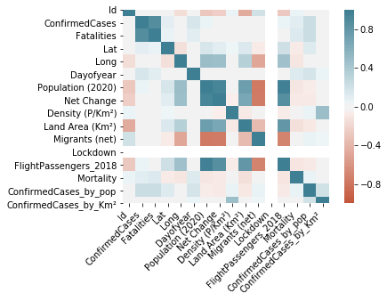

```python
# Step 0 - Read the dataset, calculate column correlations and make a seaborn heatmap

data = pd.read_csv('https://raw.githubusercontent.com/drazenz/heatmap/master/autos.clean.csv')
data.head()
corr = dftrainall.corr()
ax = sns.heatmap(
    corr,
    vmin=-1, vmax=1, center=0,
    cmap=sns.diverging_palette(20, 220, n=200),
    square=True
)
ax.set_xticklabels(
    ax.get_xticklabels(),
    rotation=45,
    horizontalalignment='right'
);
```

### 2. EDA

2.1 Data Importation of the daily-updated John Hopkins dataset

```python
allcountries_ordered = confirmed.set_index(['Country_Region']).iloc[:,-2].sort_values(ascending=False).index.tolist()
```

```python
confirmedT, deathsT, recoveredT, mortalityT = add_day(confirmedT), add_day(deathsT), add_day(recoveredT), add_day(mortalityT)
```

```python
def df_day1(df, confirmed):
    df_day1 = pd.DataFrame({'Days since 25 cases' : np.arange(1000)}).set_index('Days since 25 cases')
    countries_df = df.columns.tolist()[:-2]
    countries_conf = confirmed.columns.tolist()[:-2]
    #print(len(countries_df), len(confirmed.columns.tolist()[:-2]))
    for ic, country in enumerate(countries_df):
        for ic2, country2 in enumerate(countries_conf):
            if country == country2:
                dfsub = df[confirmed[country] > 25.][country]
                df_day1[country] = np.nan
                df_day1.loc[:len(dfsub)-1,country] = (dfsub).tolist()
        #try:
        #except:
        #    pass
    df_day1 = df_day1.dropna(how='all')
    #df_day1 = df_day1.fillna(0.)
    return df_day1
```

```python
confirmed_day1 = df_day1(confirmedT, confirmedT)
deaths_day1 = df_day1(deathsT, confirmedT)
recovered_day1 = df_day1(recoveredT, confirmedT)
mortality_day1 = df_day1(mortalityT, confirmedT)
confirmednorm_day1 = confirmed_day1/confirmed_day1.loc[0,:]
maxday = confirmed_day1.shape[0]
```

```python
date_day1 = confirmedT.copy()
for column in date_day1:
    date_day1[column] = confirmedT.index.tolist()
date_day1 = df_day1(date_day1, confirmedT)
date_day1.head()
```

| Days since 25 cases | Afghanistan | Albania | Algeria | Andorra | Angola | Antigua and Barbuda | Argentina | Armenia | Australia | Austria | ... | United Kingdom | Uruguay | Uzbekistan | Venezuela | Vietnam | West Bank and Gaza | Western Sahara | Yemen | Zambia | Zimbabwe |
| --- | --- | --- | --- | --- | --- | --- | --- | --- | --- | --- | --- | --- | --- | --- | --- | --- | --- | --- | --- | --- | --- |
| 0 | 2020-03-22 00:00:00 | 2020-03-13 00:00:00 | 2020-03-13 00:00:00 | 2020-03-17 00:00:00 | NaN | NaN | 2020-03-13 00:00:00 | 2020-03-15 00:00:00 | 2020-03-01 00:00:00 | 2020-03-04 00:00:00 | ... | 2020-03-01 00:00:00 | 2020-03-17 00:00:00 | 2020-03-20 00:00:00 | 2020-03-17 00:00:00 | 2020-03-08 00:00:00 | 2020-03-10 00:00:00 | NaN | NaN | 2020-03-28 00:00:00 | NaN |
| 1 | 2020-03-23 00:00:00 | 2020-03-14 00:00:00 | 2020-03-14 00:00:00 | 2020-03-18 00:00:00 | NaN | NaN | 2020-03-14 00:00:00 | 2020-03-16 00:00:00 | 2020-03-02 00:00:00 | 2020-03-05 00:00:00 | ... | 2020-03-02 00:00:00 | 2020-03-18 00:00:00 | 2020-03-21 00:00:00 | 2020-03-18 00:00:00 | 2020-03-09 00:00:00 | 2020-03-11 00:00:00 | NaN | NaN | 2020-03-29 00:00:00 | NaN |
| 2 | 2020-03-24 00:00:00 | 2020-03-15 00:00:00 | 2020-03-15 00:00:00 | 2020-03-19 00:00:00 | NaN | NaN | 2020-03-15 00:00:00 | 2020-03-17 00:00:00 | 2020-03-03 00:00:00 | 2020-03-06 00:00:00 | ... | 2020-03-03 00:00:00 | 2020-03-19 00:00:00 | 2020-03-22 00:00:00 | 2020-03-19 00:00:00 | 2020-03-10 00:00:00 | 2020-03-12 00:00:00 | NaN | NaN | 2020-03-30 00:00:00 | NaN |
| 3 | 2020-03-25 00:00:00 | 2020-03-16 00:00:00 | 2020-03-16 00:00:00 | 2020-03-20 00:00:00 | NaN | NaN | 2020-03-16 00:00:00 | 2020-03-18 00:00:00 | 2020-03-04 00:00:00 | 2020-03-07 00:00:00 | ... | 2020-03-04 00:00:00 | 2020-03-20 00:00:00 | 2020-03-23 00:00:00 | 2020-03-20 00:00:00 | 2020-03-11 00:00:00 | 2020-03-13 00:00:00 | NaN | NaN | 2020-03-31 00:00:00 | NaN |
| 4 | 2020-03-26 00:00:00 | 2020-03-17 00:00:00 | 2020-03-17 00:00:00 | 2020-03-21 00:00:00 | NaN | NaN | 2020-03-17 00:00:00 | 2020-03-19 00:00:00 | 2020-03-05 00:00:00 | 2020-03-08 00:00:00 | ... | 2020-03-05 00:00:00 | 2020-03-21 00:00:00 | 2020-03-24 00:00:00 | 2020-03-21 00:00:00 | 2020-03-12 00:00:00 | 2020-03-14 00:00:00 | NaN | NaN | 2020-04-01 00:00:00 | NaN |

5 rows × 185 columns

```python
confirmedT.head()
```

| Country/Region | Afghanistan | Albania | Algeria | Andorra | Angola | Antigua and Barbuda | Argentina | Armenia | Australia | Austria | ... | Uzbekistan | Venezuela | Vietnam | West Bank and Gaza | Western Sahara | Yemen | Zambia | Zimbabwe | Date | Dayofyear |
| --- | --- | --- | --- | --- | --- | --- | --- | --- | --- | --- | --- | --- | --- | --- | --- | --- | --- | --- | --- | --- | --- |
| 2020-01-22 | 0 | 0 | 0 | 0 | 0 | 0 | 0 | 0 | 0 | 0 | ... | 0 | 0 | 0 | 0 | 0 | 0 | 0 | 0 | 2020-01-22 | 22 |
| 2020-01-23 | 0 | 0 | 0 | 0 | 0 | 0 | 0 | 0 | 0 | 0 | ... | 0 | 0 | 2 | 0 | 0 | 0 | 0 | 0 | 2020-01-23 | 23 |
| 2020-01-24 | 0 | 0 | 0 | 0 | 0 | 0 | 0 | 0 | 0 | 0 | ... | 0 | 0 | 2 | 0 | 0 | 0 | 0 | 0 | 2020-01-24 | 24 |
| 2020-01-25 | 0 | 0 | 0 | 0 | 0 | 0 | 0 | 0 | 0 | 0 | ... | 0 | 0 | 2 | 0 | 0 | 0 | 0 | 0 | 2020-01-25 | 25 |
| 2020-01-26 | 0 | 0 | 0 | 0 | 0 | 0 | 0 | 0 | 4 | 0 | ... | 0 | 0 | 2 | 0 | 0 | 0 | 0 | 0 | 2020-01-26 | 26 |

5 rows × 187 columns

#### 2.2 COVID-19 evolution in the most affected countries in the world

Let's first plot the absolute number of new cases per day and deaths per day. Here, a rolling mean is used in order to smooth the curves as some data are updated every day.

[figure not shown]

```python
plt.figure(figsize=(15,10))
plt.subplots_adjust(wspace=0.2, hspace=0.2)
#
ylabels = [ 'New confirmed per day','Fatalities per day','Cumulative confirmed cases', 'Fatalities',]
ys = [
    [confirmedT.sum(axis=1).diff().rolling(2).mean(),confirmedT.drop('China',axis=1).sum(axis=1).diff().rolling(2).mean(), confirmedT['India'].diff().rolling(2).mean()],
    [deathsT.sum(axis=1).diff().rolling(2).mean(),deathsT.drop('China',axis=1).sum(axis=1).diff().rolling(2).mean(),deathsT['India'].diff().rolling(2).mean()],[confirmedT.sum(axis=1),confirmedT.drop('China',axis=1).sum(axis=1), confirmedT['China']],
    [deathsT.sum(axis=1),deathsT.drop('China',axis=1).sum(axis=1), deathsT['China']],]
loglin = ['linear', 'linear','log', 'log', ]
for iy, y in enumerate(ys):
    plt.subplot(2,2,1+iy)
    plt.xticks(rotation=60)
    plt.xlabel('Date')
    plt.ylabel(ylabels[iy])
    plt.yscale(loglin[iy])
    colour = ['cyan','purple',"pink"]
    i=0
    for y2 in y:
        plt.plot(y2, color = colour[i])
        i = i + 1
    plt.legend(['All', 'Other than China','Only China'])
#
plt.show()
```

```python
# plt.figure(figsize=(15,10))
# plt.subplots_adjust(wspace=0.2, hspace=0.2)
# #
# ylabels = ['Cumulative confirmed cases', 'Number of deceased', 'New cases per day',' Deceased per day']
# ys = [confirmedT[allcountries_ordered[:11]], deathsT[allcountries_ordered[:11]],
#     confirmedT[allcountries_ordered[:11]].diff().rolling(2).mean(), deathsT[allcountries_ordered[:11]].diff().rolling(2).mean()]
# loglin = ['log', 'log', 'linear', 'linear']
# for iy, y in enumerate(ys):
#     plt.subplot(2,2,1+iy)
#     plt.xticks(rotation=30)
#     plt.xlabel('Date')
#     plt.ylabel(ylabels[iy])
#     plt.yscale(loglin[iy])
#     plt.plot(y)
#     plt.legend(allcountries_ordered[:11])
# #
# plt.show()
```

```python
# plt.figure(0,figsize=[20,10])
# plt.subplots_adjust(wspace=0.17, hspace=0.15)
# maxday = 35
# #
# ylabels = ['Normalised number of cases','Number of deceased','Mortality rate','Percent increase of new cases','New cases per day','Deceased per day']
# ys = [confirmednorm_day1, deaths_day1, mortality_day1, confirmed_day1.diff().pct_change().rolling(1).mean()*100., confirmed_day1.diff(), deaths_day1.diff()]
# loglin = ['log', 'log', 'linear', 'linear', 'linear', 'linear']
# for iy, y in enumerate(ys):
#     plt.subplot(2,3,iy+1)
#     plt.xlabel('Number of days since 100 confirmed cases')
#     plt.ylabel(ylabels[iy])
#     plt.xlim(0,maxday+1)
#     plt.yscale(loglin[iy])
#     plt.plot(y[allcountries_ordered[:7]].rolling(2).mean())
#     plt.legend(allcountries_ordered[:7])
# #plt.show()
# plt.savefig('cases_vs_day1.png',bbox_inches='tight',transparent=False)
```

#### 2.3. COVID-19 in Italy

Define the italian regions of interest and read the csv files from the Italian Dipartimento della Protezione Civile on github

```python
# #italy = pd.read_csv('csse_covid_19_data/csse_covid_19_time_series/covid19_italy_region.csv').set_index('Date')
# #italy.index = pd.to_datetime(italy.index).date
# list_regions = ['Total', 'Lombardia', 'Veneto', 'Piemonte', 'Emilia Romagna', 'Toscana', 'Campania', 'Sicilia']
# urlitaly = 'https://raw.githubusercontent.com/pcm-dpc/COVID-19/master/dati-regioni/dpc-covid19-ita-regioni-'
# dateini = datetime(2020,2,24)
# datenow = datetime.now()
# list_dates = pd.date_range(dateini, datenow).tolist()
# dateitaly = ['%4s%2s%2s' % (str(date.year), str(date.month).zfill(2), str(date.day).zfill(2)) for date in list_dates[:-1]]
# #
# list_italy = []
# for date in dateitaly:
#     italy2 = pd.read_csv(urlitaly+date+'.csv').set_index('data')
#     italy2.head()
#     list_italy.append(italy2)
# italy = pd.concat(list_italy)
# italy.index = pd.to_datetime(italy.index).date
# italy.head(5)
```

```python
# italy_tot = italy.groupby([italy.index]).sum()
# italy_tot['denominazione_regione'] = 'Total'
# italy = italy.append(italy_tot)
```

Create variables of interest.

```python
# totalcases = [] ; totaldeaths = [] ; mortality = [] ; percentincrease = [] ; casesperday = [] ; deathsperday = []
# for region in list_regions:
#     italy2 = italy[italy['denominazione_regione'] == region]
#     totalcases.append(italy2['totale_casi'])
#     totaldeaths.append(italy2['deceduti'])
#     mortality.append(italy2['deceduti']/italy2['totale_casi'])
#     percentincrease.append(italy2['totale_casi'].pct_change().rolling(3).mean())
#     casesperday.append(italy2['totale_casi'].diff())
#     deathsperday.append(italy2['deceduti'].diff())
```

```python
# plt.figure(0,figsize=[20,10])
# plt.subplots_adjust(wspace=0.17, hspace=0.2)
# #
# ylabels = ['Number of cases','Number of deceased','Mortality rate','Percent increase of new cases','New cases per day','Deceased per day']
# ys = [totalcases, totaldeaths, mortality, percentincrease, casesperday, deathsperday]
# loglin = ['log', 'log', 'linear', 'linear', 'log', 'log']
# for iy, y in enumerate(ys):
#     plt.subplot(2,3,iy+1)
#     plt.xlabel('Date')
#     plt.ylabel(ylabels[iy])
#     if iy == 3:
#         plt.ylim(0,0.8)
#     plt.xticks(rotation=30)
#     #plt.xlim(0,maxday)
#     plt.yscale(loglin[iy])
#     for region in y:
#         plt.plot(region.rolling(2).mean()) #y.rolling(2).mean())
#     plt.legend(list_regions)
# #plt.show()
# plt.savefig('cases_vs_time_italy.png',bbox_inches='tight',transparent=False)
```

#### 3. ML modelling

```python
def create_lags(df, maxshift):
    # Shifts
    shifts = np.arange(1,maxshift+1)
    # Create a dictionary of time-shifted data
    many_shifts = {'lag_{}'.format(ii): df.shift(ii) for ii in shifts}
    # Convert them into a dataframe
    many_shifts = pd.DataFrame(many_shifts).fillna(0.)
    return many_shifts
```

```python
# Accuracy metrics
from statsmodels.tsa.stattools import acf
def forecast_accuracy(forecast, actual):
    rmsle = np.sqrt(np.mean((np.log(forecast+1)-np.log(actual+1))**2))
    mape = np.mean(np.abs(forecast - actual)/np.abs(actual))  # Mean Absolute Percentage Error
    me = np.mean(forecast - actual)             # ME
    mae = np.mean(np.abs(forecast - actual))    # MAE
    mpe = np.mean((forecast - actual)/actual)   # MPE
    rmse = np.mean((forecast - actual)**2)**.5  # RMSE
    corr = np.corrcoef(forecast, actual)[0,1]   # corr
    mins = np.amin(np.hstack([forecast[:,None],
                              actual[:,None]]), axis=1)
    maxs = np.amax(np.hstack([forecast[:,None],
                              actual[:,None]]), axis=1)
    minmax = 1 - np.mean(mins/maxs)             # minmax
    #acf1 = acf(fc-test)[1]                      # ACF1
    return({'mape':mape, 'me':me, 'mae': mae, 'rmsle' : rmsle,
            'mpe': mpe, 'rmse':rmse, #'acf1':acf1,
            'corr':corr, 'minmax':minmax})
```

```python
#import xgboost as xgb
from sklearn.ensemble import RandomForestRegressor
from sklearn.linear_model import ElasticNet
#
# define list of models and parameters
list_models = [('ElasticNet(total)', ElasticNet()),
                ('ElasticNet(daily)', ElasticNet()),
                ('ElasticNet(weeklyavg)', ElasticNet()),
               ('Random Forest Regression(3 days avg)',RandomForestRegressor(n_estimators = 1000))
              ]
#
list_params = [{'alpha' : np.logspace(-4,2,10),
                'l1_ratio' : np.array([0.6,0.7,0.8,0.9,1.])},
                {'alpha' : np.logspace(-4,2,10),
                'l1_ratio' : np.array([0.6,0.7,0.8,0.9,1.])},
                {'alpha' : np.logspace(-4,2,10),
                'l1_ratio' : np.array([0.6,0.7,0.8,0.9,1.])},
               {
            "n_estimators"      : [10,20,30],
            "max_features"      : ["auto", "sqrt", "log2"],
            "min_samples_split" : [2,4,8],
            "bootstrap": [True, False],
            },
              ]
```

```python
#!pip install xgboost
```

```python
order_countries = date_day1.loc[0,:].sort_values().index.tolist()#[:11]
order_countries = ['Spain', 'Germany','US','Italy','France','India','Iran','China', 'Singapore']
```

```python
#order_countries.remove('Diamond Princess')
order_countries = order_countries[:30]
order_countries
```

```
['Spain',
 'Germany',
 'US',
 'Italy',
 'France',
 'India',
 'Iran',
 'China',
 'Singapore']
```

```python
#import xgboost as xgb
#from sklearn.linear_model import Ridge
#from sklearn.ensemble import RandomForestRegressor
from sklearn.model_selection import TimeSeriesSplit, GridSearchCV
#
Nlags = 5
list_inpdate = ['Dayofyear']
list_rescv = ['params', 'mean_test_score', 'std_test_score', 'mean_test_score', 'std_test_score', 'rank_test_score']
#
list_train_fc = [] ; list_valid_fc = [] ; list_train = [] ; list_valid = []
list_confirmed_train_fc = [] ; list_confirmed_valid_fc = [] ; list_confirmed_train = [] ; list_confirmed_valid = []
list_bestparams = [] ; list_bestest = [] ; list_cvres = [] ; list_inpfeat = [] ; list_error = []
df_error = pd.DataFrame(index=order_countries)
#
for im, model in enumerate(list_models):
    print("model is", model)
    list_bestparams2 = [] ; list_bestest2 = [] ; list_cvres2 = [] ; list_inpfeat2 = []
    list_train_fc2 = [] ; list_valid_fc2 = [] ; list_train2 = [] ; list_valid2 = []
    list_confirmed_train_fc2 = [] ; list_confirmed_valid_fc2 = [] ; list_confirmed_train2 = [] ; list_confirmed_valid2 = []
    list_error2 = [] ; list_index = []
    for ic, country in enumerate(order_countries):
        print('Analyzing '+country+' with '+model[0])
        #
        # here the daily number of confirmed cases is used to make the TS more stationary,
        # a rolling mean of 2 is also used to smooth the curves since some data are not updated on a daily basis
        inpfeature = list_inpdate + ['lag_'+str(i+1) for i in range(Nlags)] # + list_inpfeat
        #
        if im == 0: # model directly the total number of confirmed cases
            dfcountry = confirmedT[[country, 'Dayofyear']].replace([np.inf, -np.inf], np.nan).dropna()
        elif im == 1: # model the daily number of new confirmed cases
            dfcountry = confirmedT[[country, 'Dayofyear']].diff().rolling(1).mean().replace([np.inf, -np.inf], np.nan).dropna()
        elif im == 2: # model the daily number of new confirmed cases averaged over a week (to smooth the data)
            dfcountry = confirmedT[[country, 'Dayofyear']].diff().rolling(7).mean().replace([np.inf, -np.inf], np.nan).dropna()
        elif im == 3: # model the daily number of new confirmed cases averaged over a week (to smooth the data)
            dfcountry = confirmedT[[country, 'Dayofyear']].diff().rolling(3).mean().replace([np.inf, -np.inf], np.nan).dropna()

        #
        dflag = create_lags(dfcountry[country], Nlags)
        masktrain =  dfcountry.index <= datetime(2020,3,15)
        datetrain, datevalid = dfcountry[masktrain].index[0], dfcountry[masktrain].index[-1]
        dfconfirmedcountry = confirmedT[[country, 'Dayofyear']].replace([np.inf, -np.inf], np.nan).dropna()
        confirmedstart = dfconfirmedcountry.loc[datetrain,country]
        confirmedend = dfconfirmedcountry.loc[datevalid,country]
        #
        # join all features
        dftrain2 = dflag[masktrain].join(dfcountry[masktrain])
        dfvalid2 = dflag[~masktrain].join(dfcountry[~masktrain])
        if ic > 0: # and im == 1
            inpfeature += order_countries[:ic]
            for ic2 in range(ic):
                dftrain2 = dftrain2.join(list_train2[ic2])
                dfvalid2 = dfvalid2.join(list_valid2[ic2])
                #("train 1 is", dftrain2)
        #
        # define training and validation sets
        X = dftrain2[inpfeature]#.drop(country, axis=1)
        #print("train 2 is", X)
        y = dftrain2[country]
        X_valid = dfvalid2[inpfeature]#.drop(country, axis=1)
        y_valid = dfvalid2[country]
        #
        # run grid search
        param_search = list_params[im]
        tscv = TimeSeriesSplit(n_splits=5)
        gsearch = GridSearchCV(estimator=model[1],        # choice of model
                               cv=tscv,                   # choice of splitting
                               param_grid=param_search,   # grid of parameters
                               verbose=1,                 # print messages
                               return_train_score=True,   # return train score in CV grid result
                               n_jobs=-1,                 # number of CPUs to be used
                               scoring='neg_mean_squared_error' # metrics to be used
                              )
        gsearch.fit(X, y)
        print("model is", model)
        #
        # save results
        list_bestparams2.append(gsearch.best_params_)
        list_bestest2.append(gsearch.best_estimator_)
        cvres = pd.DataFrame(gsearch.cv_results_)[list_rescv].sort_values(by='rank_test_score',ascending=True)
        list_cvres2.append(cvres)
        #print(cvres.head())
        print('Best-fit parameters: ',gsearch.best_params_,'\n \n')
        #
        # get the forecast TS
        #n_periods = len(valid.index)
        valid_fc = pd.Series(gsearch.predict(X_valid), index=X_valid.index) #gsearch.predict(X_valid)
        train_fc = pd.Series(gsearch.predict(X), index=X.index) #gsearch.predict(X)
        #
        # save the forecast
        list_train2.append(y) ; list_valid2.append(y_valid)
        list_train_fc2.append(train_fc) ; list_valid_fc2.append(valid_fc)
        list_inpfeat2.append(inpfeature)
        #
        # re-compute number of confirmed cases
        if im == 0:
            list_confirmed_train2.append(y) ; list_confirmed_valid2.append(y_valid)
            list_confirmed_train_fc2.append(train_fc) ; list_confirmed_valid_fc2.append(valid_fc)
        elif im == 1: #
            list_confirmed_train2.append(y.cumsum()+confirmedstart) ; list_confirmed_valid2.append(y_valid.cumsum()+confirmedend)
            list_confirmed_train_fc2.append(train_fc.cumsum()+confirmedstart) ; list_confirmed_valid_fc2.append(valid_fc.cumsum()+confirmedend)
        elif im == 2:
            #ytrain = (confirmedT[[country, 'Dayofyear']].diff().dropna()).loc[:datetime.datetime(2020,3,15),country]
            #yvalid = (confirmedT[[country, 'Dayofyear']].diff().dropna()).loc[datetime.datetime(2020,3,15):,country]
            list_confirmed_train2.append(y.cumsum()+confirmedstart) ; list_confirmed_valid2.append(y_valid.cumsum()+confirmedend)
            list_confirmed_train_fc2.append(train_fc.cumsum()+confirmedstart) ; list_confirmed_valid_fc2.append(valid_fc.cumsum()+confirmedend)

        elif im == 3:

            list_confirmed_train2.append(y.cumsum()+confirmedstart) ; list_confirmed_valid2.append(y_valid.cumsum()+confirmedend)
            list_confirmed_train_fc2.append(train_fc.cumsum()+confirmedstart) ; list_confirmed_valid_fc2.append(valid_fc.cumsum()+confirmedend)
        # evaluate the error
        list_error2.append(forecast_accuracy(list_confirmed_valid_fc2[-1], list_confirmed_valid2[-1])['rmsle'])
        #list_index.append(storedept)

    #
    list_train.append(list_train2) ; list_valid.append(list_valid2)
    list_train_fc.append(list_train_fc2) ; list_valid_fc.append(list_valid_fc2)
    list_confirmed_train.append(list_confirmed_train2) ; list_confirmed_valid.append(list_confirmed_valid2)
    list_confirmed_train_fc.append(list_confirmed_train_fc2) ; list_confirmed_valid_fc.append(list_confirmed_valid_fc2)
    list_bestparams.append(list_bestparams2) ; list_bestest.append(list_bestest2) ; list_cvres.append(list_cvres2)
    list_inpfeat.append(list_inpfeat2)
    #
    df_error['Error for '+model[0]] = list_error2
```

```
model is ('ElasticNet(total)', ElasticNet(alpha=1.0, copy_X=True, fit_intercept=True, l1_ratio=0.5,
           max_iter=1000, normalize=False, positive=False, precompute=False,
           random_state=None, selection='cyclic', tol=0.0001, warm_start=False))
Analyzing Spain with ElasticNet(total)
Fitting 5 folds for each of 50 candidates, totalling 250 fits
```

[output not shown]

```
model is ('ElasticNet(total)', ElasticNet(alpha=1.0, copy_X=True, fit_intercept=True, l1_ratio=0.5,
           max_iter=1000, normalize=False, positive=False, precompute=False,
           random_state=None, selection='cyclic', tol=0.0001, warm_start=False))
Best-fit parameters:  {'alpha': 100.0, 'l1_ratio': 0.7}


Analyzing Germany with ElasticNet(total)
Fitting 5 folds for each of 50 candidates, totalling 250 fits
```

[output not shown]

```
model is ('ElasticNet(total)', ElasticNet(alpha=1.0, copy_X=True, fit_intercept=True, l1_ratio=0.5,
           max_iter=1000, normalize=False, positive=False, precompute=False,
           random_state=None, selection='cyclic', tol=0.0001, warm_start=False))
Best-fit parameters:  {'alpha': 100.0, 'l1_ratio': 1.0}


Analyzing US with ElasticNet(total)
Fitting 5 folds for each of 50 candidates, totalling 250 fits
```

[output not shown]

```
model is ('ElasticNet(total)', ElasticNet(alpha=1.0, copy_X=True, fit_intercept=True, l1_ratio=0.5,
           max_iter=1000, normalize=False, positive=False, precompute=False,
           random_state=None, selection='cyclic', tol=0.0001, warm_start=False))
Best-fit parameters:  {'alpha': 0.01, 'l1_ratio': 1.0}


Analyzing Italy with ElasticNet(total)
Fitting 5 folds for each of 50 candidates, totalling 250 fits
```

[output not shown]

```
model is ('ElasticNet(total)', ElasticNet(alpha=1.0, copy_X=True, fit_intercept=True, l1_ratio=0.5,
           max_iter=1000, normalize=False, positive=False, precompute=False,
           random_state=None, selection='cyclic', tol=0.0001, warm_start=False))
Best-fit parameters:  {'alpha': 100.0, 'l1_ratio': 0.6}


Analyzing France with ElasticNet(total)
Fitting 5 folds for each of 50 candidates, totalling 250 fits
```

[output not shown]

```
model is ('ElasticNet(total)', ElasticNet(alpha=1.0, copy_X=True, fit_intercept=True, l1_ratio=0.5,
           max_iter=1000, normalize=False, positive=False, precompute=False,
           random_state=None, selection='cyclic', tol=0.0001, warm_start=False))
Best-fit parameters:  {'alpha': 100.0, 'l1_ratio': 1.0}


Analyzing India with ElasticNet(total)
Fitting 5 folds for each of 50 candidates, totalling 250 fits
```

[output not shown]

```
model is ('ElasticNet(total)', ElasticNet(alpha=1.0, copy_X=True, fit_intercept=True, l1_ratio=0.5,
           max_iter=1000, normalize=False, positive=False, precompute=False,
           random_state=None, selection='cyclic', tol=0.0001, warm_start=False))
Best-fit parameters:  {'alpha': 100.0, 'l1_ratio': 1.0}


Analyzing Iran with ElasticNet(total)
Fitting 5 folds for each of 50 candidates, totalling 250 fits
```

[output not shown]

```
model is ('ElasticNet(total)', ElasticNet(alpha=1.0, copy_X=True, fit_intercept=True, l1_ratio=0.5,
           max_iter=1000, normalize=False, positive=False, precompute=False,
           random_state=None, selection='cyclic', tol=0.0001, warm_start=False))
Best-fit parameters:  {'alpha': 100.0, 'l1_ratio': 0.6}


Analyzing China with ElasticNet(total)
Fitting 5 folds for each of 50 candidates, totalling 250 fits
```

[output not shown]

```
model is ('ElasticNet(total)', ElasticNet(alpha=1.0, copy_X=True, fit_intercept=True, l1_ratio=0.5,
           max_iter=1000, normalize=False, positive=False, precompute=False,
           random_state=None, selection='cyclic', tol=0.0001, warm_start=False))
Best-fit parameters:  {'alpha': 100.0, 'l1_ratio': 0.6}


Analyzing Singapore with ElasticNet(total)
Fitting 5 folds for each of 50 candidates, totalling 250 fits
```

[output not shown]

```
model is ('ElasticNet(total)', ElasticNet(alpha=1.0, copy_X=True, fit_intercept=True, l1_ratio=0.5,
           max_iter=1000, normalize=False, positive=False, precompute=False,
           random_state=None, selection='cyclic', tol=0.0001, warm_start=False))
Best-fit parameters:  {'alpha': 100.0, 'l1_ratio': 1.0}


model is ('ElasticNet(daily)', ElasticNet(alpha=1.0, copy_X=True, fit_intercept=True, l1_ratio=0.5,
           max_iter=1000, normalize=False, positive=False, precompute=False,
           random_state=None, selection='cyclic', tol=0.0001, warm_start=False))
Analyzing Spain with ElasticNet(daily)
Fitting 5 folds for each of 50 candidates, totalling 250 fits
```

[output not shown]

```
model is ('ElasticNet(daily)', ElasticNet(alpha=1.0, copy_X=True, fit_intercept=True, l1_ratio=0.5,
           max_iter=1000, normalize=False, positive=False, precompute=False,
           random_state=None, selection='cyclic', tol=0.0001, warm_start=False))
Best-fit parameters:  {'alpha': 100.0, 'l1_ratio': 0.6}


Analyzing Germany with ElasticNet(daily)
Fitting 5 folds for each of 50 candidates, totalling 250 fits
```

[output not shown]

```
model is ('ElasticNet(daily)', ElasticNet(alpha=1.0, copy_X=True, fit_intercept=True, l1_ratio=0.5,
           max_iter=1000, normalize=False, positive=False, precompute=False,
           random_state=None, selection='cyclic', tol=0.0001, warm_start=False))
Best-fit parameters:  {'alpha': 100.0, 'l1_ratio': 0.6}


Analyzing US with ElasticNet(daily)
Fitting 5 folds for each of 50 candidates, totalling 250 fits
```

[output not shown]

```
model is ('ElasticNet(daily)', ElasticNet(alpha=1.0, copy_X=True, fit_intercept=True, l1_ratio=0.5,
           max_iter=1000, normalize=False, positive=False, precompute=False,
           random_state=None, selection='cyclic', tol=0.0001, warm_start=False))
Best-fit parameters:  {'alpha': 21.54434690031882, 'l1_ratio': 0.9}


Analyzing Italy with ElasticNet(daily)
Fitting 5 folds for each of 50 candidates, totalling 250 fits
```

[output not shown]

```
model is ('ElasticNet(daily)', ElasticNet(alpha=1.0, copy_X=True, fit_intercept=True, l1_ratio=0.5,
           max_iter=1000, normalize=False, positive=False, precompute=False,
           random_state=None, selection='cyclic', tol=0.0001, warm_start=False))
Best-fit parameters:  {'alpha': 100.0, 'l1_ratio': 0.8}


Analyzing France with ElasticNet(daily)
Fitting 5 folds for each of 50 candidates, totalling 250 fits
```

[output not shown]

```
model is ('ElasticNet(daily)', ElasticNet(alpha=1.0, copy_X=True, fit_intercept=True, l1_ratio=0.5,
           max_iter=1000, normalize=False, positive=False, precompute=False,
           random_state=None, selection='cyclic', tol=0.0001, warm_start=False))
Best-fit parameters:  {'alpha': 100.0, 'l1_ratio': 0.6}


Analyzing India with ElasticNet(daily)
Fitting 5 folds for each of 50 candidates, totalling 250 fits
```

[output not shown]

```
model is ('ElasticNet(daily)', ElasticNet(alpha=1.0, copy_X=True, fit_intercept=True, l1_ratio=0.5,
           max_iter=1000, normalize=False, positive=False, precompute=False,
           random_state=None, selection='cyclic', tol=0.0001, warm_start=False))
Best-fit parameters:  {'alpha': 100.0, 'l1_ratio': 1.0}


Analyzing Iran with ElasticNet(daily)
Fitting 5 folds for each of 50 candidates, totalling 250 fits
```

[output not shown]

```
model is ('ElasticNet(daily)', ElasticNet(alpha=1.0, copy_X=True, fit_intercept=True, l1_ratio=0.5,
           max_iter=1000, normalize=False, positive=False, precompute=False,
           random_state=None, selection='cyclic', tol=0.0001, warm_start=False))
Best-fit parameters:  {'alpha': 100.0, 'l1_ratio': 0.6}


Analyzing China with ElasticNet(daily)
Fitting 5 folds for each of 50 candidates, totalling 250 fits
```

[output not shown]

```
model is ('ElasticNet(daily)', ElasticNet(alpha=1.0, copy_X=True, fit_intercept=True, l1_ratio=0.5,
           max_iter=1000, normalize=False, positive=False, precompute=False,
           random_state=None, selection='cyclic', tol=0.0001, warm_start=False))
Best-fit parameters:  {'alpha': 100.0, 'l1_ratio': 0.6}


Analyzing Singapore with ElasticNet(daily)
Fitting 5 folds for each of 50 candidates, totalling 250 fits
```

[output not shown]

```
model is ('ElasticNet(daily)', ElasticNet(alpha=1.0, copy_X=True, fit_intercept=True, l1_ratio=0.5,
           max_iter=1000, normalize=False, positive=False, precompute=False,
           random_state=None, selection='cyclic', tol=0.0001, warm_start=False))
Best-fit parameters:  {'alpha': 21.54434690031882, 'l1_ratio': 0.9}


model is ('ElasticNet(weeklyavg)', ElasticNet(alpha=1.0, copy_X=True, fit_intercept=True, l1_ratio=0.5,
           max_iter=1000, normalize=False, positive=False, precompute=False,
           random_state=None, selection='cyclic', tol=0.0001, warm_start=False))
Analyzing Spain with ElasticNet(weeklyavg)
Fitting 5 folds for each of 50 candidates, totalling 250 fits
```

[output not shown]

```
model is ('ElasticNet(weeklyavg)', ElasticNet(alpha=1.0, copy_X=True, fit_intercept=True, l1_ratio=0.5,
           max_iter=1000, normalize=False, positive=False, precompute=False,
           random_state=None, selection='cyclic', tol=0.0001, warm_start=False))
Best-fit parameters:  {'alpha': 0.046415888336127774, 'l1_ratio': 1.0}


Analyzing Germany with ElasticNet(weeklyavg)
Fitting 5 folds for each of 50 candidates, totalling 250 fits
```

[output not shown]

```
model is ('ElasticNet(weeklyavg)', ElasticNet(alpha=1.0, copy_X=True, fit_intercept=True, l1_ratio=0.5,
           max_iter=1000, normalize=False, positive=False, precompute=False,
           random_state=None, selection='cyclic', tol=0.0001, warm_start=False))
Best-fit parameters:  {'alpha': 100.0, 'l1_ratio': 0.8}


Analyzing US with ElasticNet(weeklyavg)
Fitting 5 folds for each of 50 candidates, totalling 250 fits
```

[output not shown]

```
model is ('ElasticNet(weeklyavg)', ElasticNet(alpha=1.0, copy_X=True, fit_intercept=True, l1_ratio=0.5,
           max_iter=1000, normalize=False, positive=False, precompute=False,
           random_state=None, selection='cyclic', tol=0.0001, warm_start=False))
Best-fit parameters:  {'alpha': 0.046415888336127774, 'l1_ratio': 1.0}


Analyzing Italy with ElasticNet(weeklyavg)
Fitting 5 folds for each of 50 candidates, totalling 250 fits
```

[output not shown]

```
model is ('ElasticNet(weeklyavg)', ElasticNet(alpha=1.0, copy_X=True, fit_intercept=True, l1_ratio=0.5,
           max_iter=1000, normalize=False, positive=False, precompute=False,
           random_state=None, selection='cyclic', tol=0.0001, warm_start=False))
Best-fit parameters:  {'alpha': 100.0, 'l1_ratio': 0.6}


Analyzing France with ElasticNet(weeklyavg)
Fitting 5 folds for each of 50 candidates, totalling 250 fits
```

[output not shown]

```
model is ('ElasticNet(weeklyavg)', ElasticNet(alpha=1.0, copy_X=True, fit_intercept=True, l1_ratio=0.5,
           max_iter=1000, normalize=False, positive=False, precompute=False,
           random_state=None, selection='cyclic', tol=0.0001, warm_start=False))
Best-fit parameters:  {'alpha': 21.54434690031882, 'l1_ratio': 1.0}


Analyzing India with ElasticNet(weeklyavg)
Fitting 5 folds for each of 50 candidates, totalling 250 fits
```

[output not shown]

```
model is ('ElasticNet(weeklyavg)', ElasticNet(alpha=1.0, copy_X=True, fit_intercept=True, l1_ratio=0.5,
           max_iter=1000, normalize=False, positive=False, precompute=False,
           random_state=None, selection='cyclic', tol=0.0001, warm_start=False))
Best-fit parameters:  {'alpha': 100.0, 'l1_ratio': 0.8}


Analyzing Iran with ElasticNet(weeklyavg)
Fitting 5 folds for each of 50 candidates, totalling 250 fits
```

[output not shown]

```
model is ('ElasticNet(weeklyavg)', ElasticNet(alpha=1.0, copy_X=True, fit_intercept=True, l1_ratio=0.5,
           max_iter=1000, normalize=False, positive=False, precompute=False,
           random_state=None, selection='cyclic', tol=0.0001, warm_start=False))
Best-fit parameters:  {'alpha': 21.54434690031882, 'l1_ratio': 0.6}


Analyzing China with ElasticNet(weeklyavg)
Fitting 5 folds for each of 50 candidates, totalling 250 fits
```

[output not shown]

```
model is ('ElasticNet(weeklyavg)', ElasticNet(alpha=1.0, copy_X=True, fit_intercept=True, l1_ratio=0.5,
           max_iter=1000, normalize=False, positive=False, precompute=False,
           random_state=None, selection='cyclic', tol=0.0001, warm_start=False))
Best-fit parameters:  {'alpha': 100.0, 'l1_ratio': 0.6}


Analyzing Singapore with ElasticNet(weeklyavg)
Fitting 5 folds for each of 50 candidates, totalling 250 fits
```

[output not shown]

```
model is ('ElasticNet(weeklyavg)', ElasticNet(alpha=1.0, copy_X=True, fit_intercept=True, l1_ratio=0.5,
           max_iter=1000, normalize=False, positive=False, precompute=False,
           random_state=None, selection='cyclic', tol=0.0001, warm_start=False))
Best-fit parameters:  {'alpha': 4.641588833612772, 'l1_ratio': 1.0}


model is ('Random Forest Regression(3 days avg)', RandomForestRegressor(bootstrap=True, criterion='mse', max_depth=None,
                      max_features='auto', max_leaf_nodes=None,
                      min_impurity_decrease=0.0, min_impurity_split=None,
                      min_samples_leaf=1, min_samples_split=2,
                      min_weight_fraction_leaf=0.0, n_estimators=1000,
                      n_jobs=None, oob_score=False, random_state=None,
                      verbose=0, warm_start=False))
Analyzing Spain with Random Forest Regression(3 days avg)
Fitting 5 folds for each of 54 candidates, totalling 270 fits
```

[output not shown]

```
model is ('Random Forest Regression(3 days avg)', RandomForestRegressor(bootstrap=True, criterion='mse', max_depth=None,
                      max_features='auto', max_leaf_nodes=None,
                      min_impurity_decrease=0.0, min_impurity_split=None,
                      min_samples_leaf=1, min_samples_split=2,
                      min_weight_fraction_leaf=0.0, n_estimators=1000,
                      n_jobs=None, oob_score=False, random_state=None,
                      verbose=0, warm_start=False))
Best-fit parameters:  {'bootstrap': False, 'max_features': 'auto', 'min_samples_split': 2, 'n_estimators': 10}


Analyzing Germany with Random Forest Regression(3 days avg)
Fitting 5 folds for each of 54 candidates, totalling 270 fits
```

[output not shown]

```
model is ('Random Forest Regression(3 days avg)', RandomForestRegressor(bootstrap=True, criterion='mse', max_depth=None,
                      max_features='auto', max_leaf_nodes=None,
                      min_impurity_decrease=0.0, min_impurity_split=None,
                      min_samples_leaf=1, min_samples_split=2,
                      min_weight_fraction_leaf=0.0, n_estimators=1000,
                      n_jobs=None, oob_score=False, random_state=None,
                      verbose=0, warm_start=False))
Best-fit parameters:  {'bootstrap': False, 'max_features': 'auto', 'min_samples_split': 2, 'n_estimators': 20}


Analyzing US with Random Forest Regression(3 days avg)
Fitting 5 folds for each of 54 candidates, totalling 270 fits
```

[output not shown]

```
model is ('Random Forest Regression(3 days avg)', RandomForestRegressor(bootstrap=True, criterion='mse', max_depth=None,
                      max_features='auto', max_leaf_nodes=None,
                      min_impurity_decrease=0.0, min_impurity_split=None,
                      min_samples_leaf=1, min_samples_split=2,
                      min_weight_fraction_leaf=0.0, n_estimators=1000,
                      n_jobs=None, oob_score=False, random_state=None,
                      verbose=0, warm_start=False))
Best-fit parameters:  {'bootstrap': False, 'max_features': 'log2', 'min_samples_split': 2, 'n_estimators': 10}


Analyzing Italy with Random Forest Regression(3 days avg)
Fitting 5 folds for each of 54 candidates, totalling 270 fits
```

[output not shown]

```
model is ('Random Forest Regression(3 days avg)', RandomForestRegressor(bootstrap=True, criterion='mse', max_depth=None,
                      max_features='auto', max_leaf_nodes=None,
                      min_impurity_decrease=0.0, min_impurity_split=None,
                      min_samples_leaf=1, min_samples_split=2,
                      min_weight_fraction_leaf=0.0, n_estimators=1000,
                      n_jobs=None, oob_score=False, random_state=None,
                      verbose=0, warm_start=False))
Best-fit parameters:  {'bootstrap': False, 'max_features': 'log2', 'min_samples_split': 2, 'n_estimators': 10}


Analyzing France with Random Forest Regression(3 days avg)
Fitting 5 folds for each of 54 candidates, totalling 270 fits
```

```
[Parallel(n_jobs=-1)]: Done  36 tasks      | elapsed:    0.3s
[Parallel(n_jobs=-1)]: Done 270 out of 270 | elapsed:    1.0s finished
[Parallel(n_jobs=-1)]: Using backend LokyBackend with 12 concurrent workers.
```

```
model is ('Random Forest Regression(3 days avg)', RandomForestRegressor(bootstrap=True, criterion='mse', max_depth=None,
                      max_features='auto', max_leaf_nodes=None,
                      min_impurity_decrease=0.0, min_impurity_split=None,
                      min_samples_leaf=1, min_samples_split=2,
                      min_weight_fraction_leaf=0.0, n_estimators=1000,
                      n_jobs=None, oob_score=False, random_state=None,
                      verbose=0, warm_start=False))
Best-fit parameters:  {'bootstrap': False, 'max_features': 'log2', 'min_samples_split': 2, 'n_estimators': 30}


Analyzing India with Random Forest Regression(3 days avg)
Fitting 5 folds for each of 54 candidates, totalling 270 fits
```

```
[Parallel(n_jobs=-1)]: Done  36 tasks      | elapsed:    0.3s
[Parallel(n_jobs=-1)]: Done 270 out of 270 | elapsed:    1.0s finished
[Parallel(n_jobs=-1)]: Using backend LokyBackend with 12 concurrent workers.
```

```
model is ('Random Forest Regression(3 days avg)', RandomForestRegressor(bootstrap=True, criterion='mse', max_depth=None,
                      max_features='auto', max_leaf_nodes=None,
                      min_impurity_decrease=0.0, min_impurity_split=None,
                      min_samples_leaf=1, min_samples_split=2,
                      min_weight_fraction_leaf=0.0, n_estimators=1000,
                      n_jobs=None, oob_score=False, random_state=None,
                      verbose=0, warm_start=False))
Best-fit parameters:  {'bootstrap': True, 'max_features': 'auto', 'min_samples_split': 8, 'n_estimators': 30}


Analyzing Iran with Random Forest Regression(3 days avg)
Fitting 5 folds for each of 54 candidates, totalling 270 fits
```

```
[Parallel(n_jobs=-1)]: Done  32 tasks      | elapsed:    0.2s
[Parallel(n_jobs=-1)]: Done 270 out of 270 | elapsed:    1.0s finished
[Parallel(n_jobs=-1)]: Using backend LokyBackend with 12 concurrent workers.
```

```
model is ('Random Forest Regression(3 days avg)', RandomForestRegressor(bootstrap=True, criterion='mse', max_depth=None,
                      max_features='auto', max_leaf_nodes=None,
                      min_impurity_decrease=0.0, min_impurity_split=None,
                      min_samples_leaf=1, min_samples_split=2,
                      min_weight_fraction_leaf=0.0, n_estimators=1000,
                      n_jobs=None, oob_score=False, random_state=None,
                      verbose=0, warm_start=False))
Best-fit parameters:  {'bootstrap': False, 'max_features': 'sqrt', 'min_samples_split': 2, 'n_estimators': 30}


Analyzing China with Random Forest Regression(3 days avg)
Fitting 5 folds for each of 54 candidates, totalling 270 fits
```

```
[Parallel(n_jobs=-1)]: Done  36 tasks      | elapsed:    0.2s
[Parallel(n_jobs=-1)]: Done 270 out of 270 | elapsed:    1.0s finished
[Parallel(n_jobs=-1)]: Using backend LokyBackend with 12 concurrent workers.
```

```
model is ('Random Forest Regression(3 days avg)', RandomForestRegressor(bootstrap=True, criterion='mse', max_depth=None,
                      max_features='auto', max_leaf_nodes=None,
                      min_impurity_decrease=0.0, min_impurity_split=None,
                      min_samples_leaf=1, min_samples_split=2,
                      min_weight_fraction_leaf=0.0, n_estimators=1000,
                      n_jobs=None, oob_score=False, random_state=None,
                      verbose=0, warm_start=False))
Best-fit parameters:  {'bootstrap': True, 'max_features': 'auto', 'min_samples_split': 2, 'n_estimators': 20}


Analyzing Singapore with Random Forest Regression(3 days avg)
Fitting 5 folds for each of 54 candidates, totalling 270 fits
model is ('Random Forest Regression(3 days avg)', RandomForestRegressor(bootstrap=True, criterion='mse', max_depth=None,
                      max_features='auto', max_leaf_nodes=None,
                      min_impurity_decrease=0.0, min_impurity_split=None,
                      min_samples_leaf=1, min_samples_split=2,
                      min_weight_fraction_leaf=0.0, n_estimators=1000,
                      n_jobs=None, oob_score=False, random_state=None,
                      verbose=0, warm_start=False))
Best-fit parameters:  {'bootstrap': False, 'max_features': 'auto', 'min_samples_split': 2, 'n_estimators': 10}
```

```
[Parallel(n_jobs=-1)]: Done 270 out of 270 | elapsed:    1.0s finished
```

List the RMSLE error for our different models.

```python
df_error.head(10)
```

|  | Error for ElasticNet(total) | Error for ElasticNet(daily) | Error for ElasticNet(weeklyavg) | Error for Random Forest Regression(3 days avg) |
| --- | --- | --- | --- | --- |
| Spain | 1.209270 | 1.577903 | 0.942412 | 0.817409 |
| Germany | 0.113194 | 0.053559 | 0.088449 | 0.920632 |
| US | 0.297392 | 0.558661 | 0.330236 | 2.568812 |
| Italy | 0.654663 | 0.521654 | 1.038879 | 0.134008 |
| France | 0.473813 | 1.558911 | 0.041920 | 1.114307 |
| India | 2.337919 | 0.436289 | 1.639091 | 2.284670 |
| Iran | 1.407881 | 0.770526 | 1.023687 | 0.265913 |
| China | 0.915866 | 0.851847 | 1.284707 | 0.012710 |
| Singapore | 1.275727 | 0.536589 | 0.709729 | 1.006567 |

```python
df_error.to_csv("confirmederrors.csv")
```

Compare our forecast with actual evolution both for training and validation sets.

```python
# Compare predicted and actual test TS
def plot_forecast(country, train, trainfc, valid, validfc, validfclower, validfcupper, plottitle):
    #fig, axes = plt.subplots(1, 1, figsize=(10,3), dpi=100, sharex=True)
    plt.xticks(rotation=15)
    plt.plot(train, label='Training Actuals', color='Purple')
    plt.plot(trainfc, label='Training Forecasts', color='Purple', ls='--')
    plt.plot(valid, label='Validation Actual', color='Cyan', ls='-')
    plt.ylabel('Covid Confirmed numbers')
    try:
        plt.fill_between(validfclower.index,
                         validfclower,
                         validfcupper,
                         color='k', alpha=.15)
    except:
        pass
    plt.plot(validfc, label='Validation Forcast', color='Cyan', ls='--')
    plt.legend()
    plt.title("Forecast of "+str(country)+" with "+plottitle)
    #plt.show()
```

```python
order_countries2 = order_countries[:11]
```

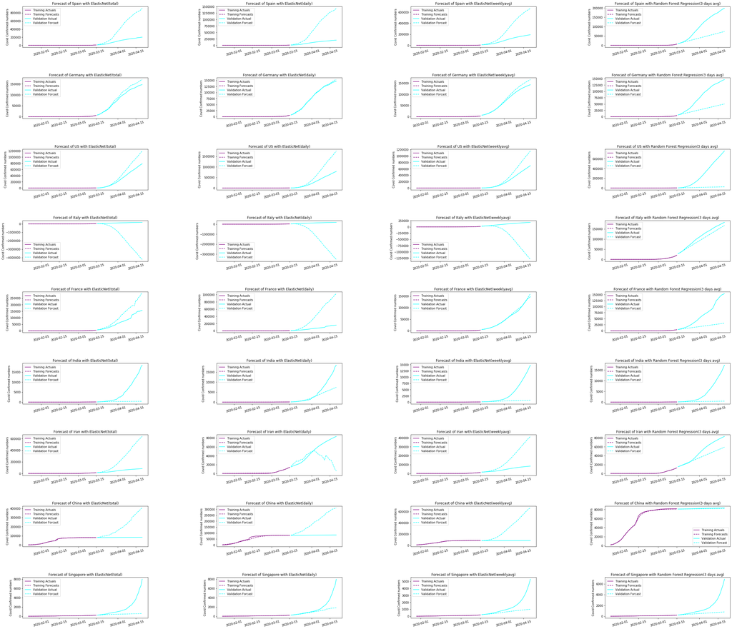

```python
plt.figure(0,figsize=[45,40])
plt.subplots_adjust(wspace=0.55, hspace=0.75)
iy = 0
for ic, country in enumerate(order_countries2): #allcountries_ordered:
    for im, model in enumerate(list_models):
        plt.subplot(len(order_countries2),len(list_models), iy+1)
        train = list_confirmed_train[im][ic] ; valid = list_confirmed_valid[im][ic]
        train_fc = list_confirmed_train_fc[im][ic] ; valid_fc = list_confirmed_valid_fc[im][ic]
        plot_forecast(country, train, train_fc, valid, valid_fc, 0., 0., model[0])
        iy += 1
plt.show()
```

## Same For Deaths

```python
Nlags = 5
list_inpdate = ['Dayofyear']
list_rescv = ['params', 'mean_test_score', 'std_test_score', 'mean_test_score', 'std_test_score', 'rank_test_score']
#
list_train_fc = [] ; list_valid_fc = [] ; list_train = [] ; list_valid = []
list_deaths_train_fc = [] ; list_deaths_valid_fc = [] ; list_deaths_train = [] ; list_deaths_valid = []
list_bestparams = [] ; list_bestest = [] ; list_cvres = [] ; list_inpfeat = [] ; list_error = []
df_error = pd.DataFrame(index=order_countries)
#
for im, model in enumerate(list_models):
    print("model is", model)
    list_bestparams2 = [] ; list_bestest2 = [] ; list_cvres2 = [] ; list_inpfeat2 = []
    list_train_fc2 = [] ; list_valid_fc2 = [] ; list_train2 = [] ; list_valid2 = []
    list_deaths_train_fc2 = [] ; list_deaths_valid_fc2 = [] ; list_deaths_train2 = [] ; list_deaths_valid2 = []
    list_error2 = [] ; list_index = []
    for ic, country in enumerate(order_countries):
        print('Analyzing '+country+' with '+model[0])
        #
        # here the daily number of deaths cases is used to make the TS more stationary,
        # a rolling mean of 2 is also used to smooth the curves since some data are not updated on a daily basis
        inpfeature = list_inpdate + ['lag_'+str(i+1) for i in range(Nlags)] # + list_inpfeat
        #
        if im == 0: # model directly the total number of deaths cases
            dfcountry = deathsT[[country, 'Dayofyear']].replace([np.inf, -np.inf], np.nan).dropna()
        elif im == 1: # model the daily number of new deaths cases
            dfcountry = deathsT[[country, 'Dayofyear']].diff().rolling(1).mean().replace([np.inf, -np.inf], np.nan).dropna()
        elif im == 2: # model the daily number of new deaths cases averaged over a week (to smooth the data)
            dfcountry = deathsT[[country, 'Dayofyear']].diff().rolling(7).mean().replace([np.inf, -np.inf], np.nan).dropna()
        elif im == 3: # model the daily number of new deaths cases averaged over a week (to smooth the data)
            dfcountry = deathsT[[country, 'Dayofyear']].diff().rolling(3).mean().replace([np.inf, -np.inf], np.nan).dropna()

        #
        dflag = create_lags(dfcountry[country], Nlags)
        masktrain =  dfcountry.index <= datetime(2020,3,15)
        datetrain, datevalid = dfcountry[masktrain].index[0], dfcountry[masktrain].index[-1]
        dfdeathscountry = deathsT[[country, 'Dayofyear']].replace([np.inf, -np.inf], np.nan).dropna()
        deathsstart = dfdeathscountry.loc[datetrain,country]
        deathsend = dfdeathscountry.loc[datevalid,country]
        #
        # join all features
        dftrain2 = dflag[masktrain].join(dfcountry[masktrain])
        dfvalid2 = dflag[~masktrain].join(dfcountry[~masktrain])
        if ic > 0: # and im == 1
            inpfeature += order_countries[:ic]
            for ic2 in range(ic):
                dftrain2 = dftrain2.join(list_train2[ic2])
                dfvalid2 = dfvalid2.join(list_valid2[ic2])
                #("train 1 is", dftrain2)
        #
        # define training and validation sets
        X = dftrain2[inpfeature]#.drop(country, axis=1)
        #print("train 2 is", X)
        y = dftrain2[country]
        X_valid = dfvalid2[inpfeature]#.drop(country, axis=1)
        y_valid = dfvalid2[country]
        #
        # run grid search
        param_search = list_params[im]
        tscv = TimeSeriesSplit(n_splits=5)
        gsearch = GridSearchCV(estimator=model[1],        # choice of model
                               cv=tscv,                   # choice of splitting
                               param_grid=param_search,   # grid of parameters
                               verbose=1,                 # print messages
                               return_train_score=True,   # return train score in CV grid result
                               n_jobs=-1,                 # number of CPUs to be used
                               scoring='neg_mean_squared_error' # metrics to be used
                              )
        gsearch.fit(X, y)
        print("model is", model)
        #
        # save results
        list_bestparams2.append(gsearch.best_params_)
        list_bestest2.append(gsearch.best_estimator_)
        cvres = pd.DataFrame(gsearch.cv_results_)[list_rescv].sort_values(by='rank_test_score',ascending=True)
        list_cvres2.append(cvres)
        #print(cvres.head())
        print('Best-fit parameters: ',gsearch.best_params_,'\n \n')
        #
        # get the forecast TS
        #n_periods = len(valid.index)
        valid_fc = pd.Series(gsearch.predict(X_valid), index=X_valid.index) #gsearch.predict(X_valid)
        train_fc = pd.Series(gsearch.predict(X), index=X.index) #gsearch.predict(X)
        #
        # save the forecast
        list_train2.append(y) ; list_valid2.append(y_valid)
        list_train_fc2.append(train_fc) ; list_valid_fc2.append(valid_fc)
        list_inpfeat2.append(inpfeature)
        #
        # re-compute number of deaths cases
        if im == 0:
            list_deaths_train2.append(y) ; list_deaths_valid2.append(y_valid)
            list_deaths_train_fc2.append(train_fc) ; list_deaths_valid_fc2.append(valid_fc)
        elif im == 1: #
            list_deaths_train2.append(y.cumsum()+deathsstart) ; list_deaths_valid2.append(y_valid.cumsum()+deathsend)
            list_deaths_train_fc2.append(train_fc.cumsum()+deathsstart) ; list_deaths_valid_fc2.append(valid_fc.cumsum()+deathsend)
        elif im == 2:
            #ytrain = (deathsT[[country, 'Dayofyear']].diff().dropna()).loc[:datetime.datetime(2020,3,15),country]
            #yvalid = (deathsT[[country, 'Dayofyear']].diff().dropna()).loc[datetime.datetime(2020,3,15):,country]
            list_deaths_train2.append(y.cumsum()+deathsstart) ; list_deaths_valid2.append(y_valid.cumsum()+deathsend)
            list_deaths_train_fc2.append(train_fc.cumsum()+deathsstart) ; list_deaths_valid_fc2.append(valid_fc.cumsum()+deathsend)

        elif im == 3:

            list_deaths_train2.append(y.cumsum()+deathsstart) ; list_deaths_valid2.append(y_valid.cumsum()+deathsend)
            list_deaths_train_fc2.append(train_fc.cumsum()+deathsstart) ; list_deaths_valid_fc2.append(valid_fc.cumsum()+deathsend)
        # evaluate the error
        list_error2.append(forecast_accuracy(list_deaths_valid_fc2[-1], list_deaths_valid2[-1])['rmsle'])
        #list_index.append(storedept)

    #
    list_train.append(list_train2) ; list_valid.append(list_valid2)
    list_train_fc.append(list_train_fc2) ; list_valid_fc.append(list_valid_fc2)
    list_deaths_train.append(list_deaths_train2) ; list_deaths_valid.append(list_deaths_valid2)
    list_deaths_train_fc.append(list_deaths_train_fc2) ; list_deaths_valid_fc.append(list_deaths_valid_fc2)
    list_bestparams.append(list_bestparams2) ; list_bestest.append(list_bestest2) ; list_cvres.append(list_cvres2)
    list_inpfeat.append(list_inpfeat2)
    #
    df_error['Error for '+model[0]] = list_error2
```

```
model is ('ElasticNet(total)', ElasticNet(alpha=1.0, copy_X=True, fit_intercept=True, l1_ratio=0.5,
           max_iter=1000, normalize=False, positive=False, precompute=False,
           random_state=None, selection='cyclic', tol=0.0001, warm_start=False))
Analyzing Spain with ElasticNet(total)
Fitting 5 folds for each of 50 candidates, totalling 250 fits
```

```
[Parallel(n_jobs=-1)]: Using backend LokyBackend with 12 concurrent workers.
[Parallel(n_jobs=-1)]: Done  26 tasks      | elapsed:    3.6s
[Parallel(n_jobs=-1)]: Done 250 out of 250 | elapsed:    3.8s finished
[Parallel(n_jobs=-1)]: Using backend LokyBackend with 12 concurrent workers.
```

```
model is ('ElasticNet(total)', ElasticNet(alpha=1.0, copy_X=True, fit_intercept=True, l1_ratio=0.5,
           max_iter=1000, normalize=False, positive=False, precompute=False,
           random_state=None, selection='cyclic', tol=0.0001, warm_start=False))
Best-fit parameters:  {'alpha': 0.01, 'l1_ratio': 0.6}


Analyzing Germany with ElasticNet(total)
Fitting 5 folds for each of 50 candidates, totalling 250 fits
```

```
[Parallel(n_jobs=-1)]: Done 250 out of 250 | elapsed:    0.2s finished
[Parallel(n_jobs=-1)]: Using backend LokyBackend with 12 concurrent workers.
```

```
model is ('ElasticNet(total)', ElasticNet(alpha=1.0, copy_X=True, fit_intercept=True, l1_ratio=0.5,
           max_iter=1000, normalize=False, positive=False, precompute=False,
           random_state=None, selection='cyclic', tol=0.0001, warm_start=False))
Best-fit parameters:  {'alpha': 0.0001, 'l1_ratio': 0.6}


Analyzing US with ElasticNet(total)
Fitting 5 folds for each of 50 candidates, totalling 250 fits
```

```
[Parallel(n_jobs=-1)]: Done 250 out of 250 | elapsed:    0.2s finished
[Parallel(n_jobs=-1)]: Using backend LokyBackend with 12 concurrent workers.
```

```
model is ('ElasticNet(total)', ElasticNet(alpha=1.0, copy_X=True, fit_intercept=True, l1_ratio=0.5,
           max_iter=1000, normalize=False, positive=False, precompute=False,
           random_state=None, selection='cyclic', tol=0.0001, warm_start=False))
Best-fit parameters:  {'alpha': 0.21544346900318823, 'l1_ratio': 0.6}


Analyzing Italy with ElasticNet(total)
Fitting 5 folds for each of 50 candidates, totalling 250 fits
```

```
[Parallel(n_jobs=-1)]: Done 250 out of 250 | elapsed:    0.2s finished
[Parallel(n_jobs=-1)]: Using backend LokyBackend with 12 concurrent workers.
```

```
model is ('ElasticNet(total)', ElasticNet(alpha=1.0, copy_X=True, fit_intercept=True, l1_ratio=0.5,
           max_iter=1000, normalize=False, positive=False, precompute=False,
           random_state=None, selection='cyclic', tol=0.0001, warm_start=False))
Best-fit parameters:  {'alpha': 0.046415888336127774, 'l1_ratio': 1.0}


Analyzing France with ElasticNet(total)
Fitting 5 folds for each of 50 candidates, totalling 250 fits
```

```
[Parallel(n_jobs=-1)]: Done 250 out of 250 | elapsed:    0.2s finished
[Parallel(n_jobs=-1)]: Using backend LokyBackend with 12 concurrent workers.
```

```
model is ('ElasticNet(total)', ElasticNet(alpha=1.0, copy_X=True, fit_intercept=True, l1_ratio=0.5,
           max_iter=1000, normalize=False, positive=False, precompute=False,
           random_state=None, selection='cyclic', tol=0.0001, warm_start=False))
Best-fit parameters:  {'alpha': 0.01, 'l1_ratio': 1.0}


Analyzing India with ElasticNet(total)
Fitting 5 folds for each of 50 candidates, totalling 250 fits
```

```
[Parallel(n_jobs=-1)]: Done 250 out of 250 | elapsed:    0.2s finished
[Parallel(n_jobs=-1)]: Using backend LokyBackend with 12 concurrent workers.
```

```
model is ('ElasticNet(total)', ElasticNet(alpha=1.0, copy_X=True, fit_intercept=True, l1_ratio=0.5,
           max_iter=1000, normalize=False, positive=False, precompute=False,
           random_state=None, selection='cyclic', tol=0.0001, warm_start=False))
Best-fit parameters:  {'alpha': 0.0001, 'l1_ratio': 0.6}


Analyzing Iran with ElasticNet(total)
Fitting 5 folds for each of 50 candidates, totalling 250 fits
```

```
[Parallel(n_jobs=-1)]: Done 250 out of 250 | elapsed:    0.2s finished
[Parallel(n_jobs=-1)]: Using backend LokyBackend with 12 concurrent workers.
```

```
model is ('ElasticNet(total)', ElasticNet(alpha=1.0, copy_X=True, fit_intercept=True, l1_ratio=0.5,
           max_iter=1000, normalize=False, positive=False, precompute=False,
           random_state=None, selection='cyclic', tol=0.0001, warm_start=False))
Best-fit parameters:  {'alpha': 4.641588833612772, 'l1_ratio': 0.6}


Analyzing China with ElasticNet(total)
Fitting 5 folds for each of 50 candidates, totalling 250 fits
```

```
[Parallel(n_jobs=-1)]: Done 250 out of 250 | elapsed:    0.2s finished
[Parallel(n_jobs=-1)]: Using backend LokyBackend with 12 concurrent workers.
```

```
model is ('ElasticNet(total)', ElasticNet(alpha=1.0, copy_X=True, fit_intercept=True, l1_ratio=0.5,
           max_iter=1000, normalize=False, positive=False, precompute=False,
           random_state=None, selection='cyclic', tol=0.0001, warm_start=False))
Best-fit parameters:  {'alpha': 100.0, 'l1_ratio': 1.0}


Analyzing Singapore with ElasticNet(total)
Fitting 5 folds for each of 50 candidates, totalling 250 fits
```

```
[Parallel(n_jobs=-1)]: Done 250 out of 250 | elapsed:    0.2s finished
[Parallel(n_jobs=-1)]: Using backend LokyBackend with 12 concurrent workers.
```

```
model is ('ElasticNet(total)', ElasticNet(alpha=1.0, copy_X=True, fit_intercept=True, l1_ratio=0.5,
           max_iter=1000, normalize=False, positive=False, precompute=False,
           random_state=None, selection='cyclic', tol=0.0001, warm_start=False))
Best-fit parameters:  {'alpha': 0.0001, 'l1_ratio': 0.6}


model is ('ElasticNet(daily)', ElasticNet(alpha=1.0, copy_X=True, fit_intercept=True, l1_ratio=0.5,
           max_iter=1000, normalize=False, positive=False, precompute=False,
           random_state=None, selection='cyclic', tol=0.0001, warm_start=False))
Analyzing Spain with ElasticNet(daily)
Fitting 5 folds for each of 50 candidates, totalling 250 fits
```

```
[Parallel(n_jobs=-1)]: Done  40 tasks      | elapsed:    0.1s
[Parallel(n_jobs=-1)]: Done 250 out of 250 | elapsed:    0.2s finished
[Parallel(n_jobs=-1)]: Using backend LokyBackend with 12 concurrent workers.
```

```
model is ('ElasticNet(daily)', ElasticNet(alpha=1.0, copy_X=True, fit_intercept=True, l1_ratio=0.5,
           max_iter=1000, normalize=False, positive=False, precompute=False,
           random_state=None, selection='cyclic', tol=0.0001, warm_start=False))
Best-fit parameters:  {'alpha': 0.0001, 'l1_ratio': 1.0}


Analyzing Germany with ElasticNet(daily)
Fitting 5 folds for each of 50 candidates, totalling 250 fits
```

```
[Parallel(n_jobs=-1)]: Done 250 out of 250 | elapsed:    0.2s finished
[Parallel(n_jobs=-1)]: Using backend LokyBackend with 12 concurrent workers.
```

```
model is ('ElasticNet(daily)', ElasticNet(alpha=1.0, copy_X=True, fit_intercept=True, l1_ratio=0.5,
           max_iter=1000, normalize=False, positive=False, precompute=False,
           random_state=None, selection='cyclic', tol=0.0001, warm_start=False))
Best-fit parameters:  {'alpha': 0.0001, 'l1_ratio': 0.6}


Analyzing US with ElasticNet(daily)
Fitting 5 folds for each of 50 candidates, totalling 250 fits
```

```
[Parallel(n_jobs=-1)]: Done 250 out of 250 | elapsed:    0.2s finished
[Parallel(n_jobs=-1)]: Using backend LokyBackend with 12 concurrent workers.
```

```
model is ('ElasticNet(daily)', ElasticNet(alpha=1.0, copy_X=True, fit_intercept=True, l1_ratio=0.5,
           max_iter=1000, normalize=False, positive=False, precompute=False,
           random_state=None, selection='cyclic', tol=0.0001, warm_start=False))
Best-fit parameters:  {'alpha': 0.046415888336127774, 'l1_ratio': 1.0}


Analyzing Italy with ElasticNet(daily)
Fitting 5 folds for each of 50 candidates, totalling 250 fits
```

```
[Parallel(n_jobs=-1)]: Done 250 out of 250 | elapsed:    0.2s finished
[Parallel(n_jobs=-1)]: Using backend LokyBackend with 12 concurrent workers.
```

```
model is ('ElasticNet(daily)', ElasticNet(alpha=1.0, copy_X=True, fit_intercept=True, l1_ratio=0.5,
           max_iter=1000, normalize=False, positive=False, precompute=False,
           random_state=None, selection='cyclic', tol=0.0001, warm_start=False))
Best-fit parameters:  {'alpha': 21.54434690031882, 'l1_ratio': 0.6}


Analyzing France with ElasticNet(daily)
Fitting 5 folds for each of 50 candidates, totalling 250 fits
```

```
[Parallel(n_jobs=-1)]: Done 250 out of 250 | elapsed:    0.2s finished
[Parallel(n_jobs=-1)]: Using backend LokyBackend with 12 concurrent workers.
```

```
model is ('ElasticNet(daily)', ElasticNet(alpha=1.0, copy_X=True, fit_intercept=True, l1_ratio=0.5,
           max_iter=1000, normalize=False, positive=False, precompute=False,
           random_state=None, selection='cyclic', tol=0.0001, warm_start=False))
Best-fit parameters:  {'alpha': 0.046415888336127774, 'l1_ratio': 0.9}


Analyzing India with ElasticNet(daily)
Fitting 5 folds for each of 50 candidates, totalling 250 fits
```

```
[Parallel(n_jobs=-1)]: Done 250 out of 250 | elapsed:    0.2s finished
[Parallel(n_jobs=-1)]: Using backend LokyBackend with 12 concurrent workers.
```

```
model is ('ElasticNet(daily)', ElasticNet(alpha=1.0, copy_X=True, fit_intercept=True, l1_ratio=0.5,
           max_iter=1000, normalize=False, positive=False, precompute=False,
           random_state=None, selection='cyclic', tol=0.0001, warm_start=False))
Best-fit parameters:  {'alpha': 0.0001, 'l1_ratio': 0.6}


Analyzing Iran with ElasticNet(daily)
Fitting 5 folds for each of 50 candidates, totalling 250 fits
```

```
[Parallel(n_jobs=-1)]: Done 250 out of 250 | elapsed:    0.2s finished
[Parallel(n_jobs=-1)]: Using backend LokyBackend with 12 concurrent workers.
```

```
model is ('ElasticNet(daily)', ElasticNet(alpha=1.0, copy_X=True, fit_intercept=True, l1_ratio=0.5,
           max_iter=1000, normalize=False, positive=False, precompute=False,
           random_state=None, selection='cyclic', tol=0.0001, warm_start=False))
Best-fit parameters:  {'alpha': 1.0, 'l1_ratio': 1.0}


Analyzing China with ElasticNet(daily)
Fitting 5 folds for each of 50 candidates, totalling 250 fits
```

```
[Parallel(n_jobs=-1)]: Done 250 out of 250 | elapsed:    0.2s finished
[Parallel(n_jobs=-1)]: Using backend LokyBackend with 12 concurrent workers.
```

```
model is ('ElasticNet(daily)', ElasticNet(alpha=1.0, copy_X=True, fit_intercept=True, l1_ratio=0.5,
           max_iter=1000, normalize=False, positive=False, precompute=False,
           random_state=None, selection='cyclic', tol=0.0001, warm_start=False))
Best-fit parameters:  {'alpha': 100.0, 'l1_ratio': 0.8}


Analyzing Singapore with ElasticNet(daily)
Fitting 5 folds for each of 50 candidates, totalling 250 fits
```

```
[Parallel(n_jobs=-1)]: Done 250 out of 250 | elapsed:    0.2s finished
[Parallel(n_jobs=-1)]: Using backend LokyBackend with 12 concurrent workers.
```

```
model is ('ElasticNet(daily)', ElasticNet(alpha=1.0, copy_X=True, fit_intercept=True, l1_ratio=0.5,
           max_iter=1000, normalize=False, positive=False, precompute=False,
           random_state=None, selection='cyclic', tol=0.0001, warm_start=False))
Best-fit parameters:  {'alpha': 0.0001, 'l1_ratio': 0.6}


model is ('ElasticNet(weeklyavg)', ElasticNet(alpha=1.0, copy_X=True, fit_intercept=True, l1_ratio=0.5,
           max_iter=1000, normalize=False, positive=False, precompute=False,
           random_state=None, selection='cyclic', tol=0.0001, warm_start=False))
Analyzing Spain with ElasticNet(weeklyavg)
Fitting 5 folds for each of 50 candidates, totalling 250 fits
```

```
[Parallel(n_jobs=-1)]: Done  40 tasks      | elapsed:    0.1s
[Parallel(n_jobs=-1)]: Done 250 out of 250 | elapsed:    0.2s finished
[Parallel(n_jobs=-1)]: Using backend LokyBackend with 12 concurrent workers.
```

```
model is ('ElasticNet(weeklyavg)', ElasticNet(alpha=1.0, copy_X=True, fit_intercept=True, l1_ratio=0.5,
           max_iter=1000, normalize=False, positive=False, precompute=False,
           random_state=None, selection='cyclic', tol=0.0001, warm_start=False))
Best-fit parameters:  {'alpha': 0.01, 'l1_ratio': 0.6}


Analyzing Germany with ElasticNet(weeklyavg)
Fitting 5 folds for each of 50 candidates, totalling 250 fits
```

```
[Parallel(n_jobs=-1)]: Done  40 tasks      | elapsed:    0.1s
[Parallel(n_jobs=-1)]: Done 250 out of 250 | elapsed:    0.2s finished
[Parallel(n_jobs=-1)]: Using backend LokyBackend with 12 concurrent workers.
```

```
model is ('ElasticNet(weeklyavg)', ElasticNet(alpha=1.0, copy_X=True, fit_intercept=True, l1_ratio=0.5,
           max_iter=1000, normalize=False, positive=False, precompute=False,
           random_state=None, selection='cyclic', tol=0.0001, warm_start=False))
Best-fit parameters:  {'alpha': 0.0001, 'l1_ratio': 0.6}


Analyzing US with ElasticNet(weeklyavg)
Fitting 5 folds for each of 50 candidates, totalling 250 fits
```

```
[Parallel(n_jobs=-1)]: Done 250 out of 250 | elapsed:    0.1s finished
[Parallel(n_jobs=-1)]: Using backend LokyBackend with 12 concurrent workers.
```

```
model is ('ElasticNet(weeklyavg)', ElasticNet(alpha=1.0, copy_X=True, fit_intercept=True, l1_ratio=0.5,
           max_iter=1000, normalize=False, positive=False, precompute=False,
           random_state=None, selection='cyclic', tol=0.0001, warm_start=False))
Best-fit parameters:  {'alpha': 0.046415888336127774, 'l1_ratio': 0.6}


Analyzing Italy with ElasticNet(weeklyavg)
Fitting 5 folds for each of 50 candidates, totalling 250 fits
```

```
[Parallel(n_jobs=-1)]: Done  36 tasks      | elapsed:    0.1s
[Parallel(n_jobs=-1)]: Done 250 out of 250 | elapsed:    0.2s finished
[Parallel(n_jobs=-1)]: Using backend LokyBackend with 12 concurrent workers.
```

```
model is ('ElasticNet(weeklyavg)', ElasticNet(alpha=1.0, copy_X=True, fit_intercept=True, l1_ratio=0.5,
           max_iter=1000, normalize=False, positive=False, precompute=False,
           random_state=None, selection='cyclic', tol=0.0001, warm_start=False))
Best-fit parameters:  {'alpha': 4.641588833612772, 'l1_ratio': 0.7}


Analyzing France with ElasticNet(weeklyavg)
Fitting 5 folds for each of 50 candidates, totalling 250 fits
```

```
[Parallel(n_jobs=-1)]: Done 250 out of 250 | elapsed:    0.2s finished
[Parallel(n_jobs=-1)]: Using backend LokyBackend with 12 concurrent workers.
```

```
model is ('ElasticNet(weeklyavg)', ElasticNet(alpha=1.0, copy_X=True, fit_intercept=True, l1_ratio=0.5,
           max_iter=1000, normalize=False, positive=False, precompute=False,
           random_state=None, selection='cyclic', tol=0.0001, warm_start=False))
Best-fit parameters:  {'alpha': 0.01, 'l1_ratio': 0.7}


Analyzing India with ElasticNet(weeklyavg)
Fitting 5 folds for each of 50 candidates, totalling 250 fits
```

```
[Parallel(n_jobs=-1)]: Done 250 out of 250 | elapsed:    0.2s finished
[Parallel(n_jobs=-1)]: Using backend LokyBackend with 12 concurrent workers.
```

```
model is ('ElasticNet(weeklyavg)', ElasticNet(alpha=1.0, copy_X=True, fit_intercept=True, l1_ratio=0.5,
           max_iter=1000, normalize=False, positive=False, precompute=False,
           random_state=None, selection='cyclic', tol=0.0001, warm_start=False))
Best-fit parameters:  {'alpha': 0.0001, 'l1_ratio': 0.6}


Analyzing Iran with ElasticNet(weeklyavg)
Fitting 5 folds for each of 50 candidates, totalling 250 fits
```

```
[Parallel(n_jobs=-1)]: Done 250 out of 250 | elapsed:    0.2s finished
[Parallel(n_jobs=-1)]: Using backend LokyBackend with 12 concurrent workers.
```

```
model is ('ElasticNet(weeklyavg)', ElasticNet(alpha=1.0, copy_X=True, fit_intercept=True, l1_ratio=0.5,
           max_iter=1000, normalize=False, positive=False, precompute=False,
           random_state=None, selection='cyclic', tol=0.0001, warm_start=False))
Best-fit parameters:  {'alpha': 0.046415888336127774, 'l1_ratio': 1.0}


Analyzing China with ElasticNet(weeklyavg)
Fitting 5 folds for each of 50 candidates, totalling 250 fits
```

```
[Parallel(n_jobs=-1)]: Done 250 out of 250 | elapsed:    0.2s finished
[Parallel(n_jobs=-1)]: Using backend LokyBackend with 12 concurrent workers.
```

```
model is ('ElasticNet(weeklyavg)', ElasticNet(alpha=1.0, copy_X=True, fit_intercept=True, l1_ratio=0.5,
           max_iter=1000, normalize=False, positive=False, precompute=False,
           random_state=None, selection='cyclic', tol=0.0001, warm_start=False))
Best-fit parameters:  {'alpha': 21.54434690031882, 'l1_ratio': 0.8}


Analyzing Singapore with ElasticNet(weeklyavg)
Fitting 5 folds for each of 50 candidates, totalling 250 fits
```

```
[Parallel(n_jobs=-1)]: Done 250 out of 250 | elapsed:    0.2s finished
[Parallel(n_jobs=-1)]: Using backend LokyBackend with 12 concurrent workers.
```

```
model is ('ElasticNet(weeklyavg)', ElasticNet(alpha=1.0, copy_X=True, fit_intercept=True, l1_ratio=0.5,
           max_iter=1000, normalize=False, positive=False, precompute=False,
           random_state=None, selection='cyclic', tol=0.0001, warm_start=False))
Best-fit parameters:  {'alpha': 0.0001, 'l1_ratio': 0.6}


model is ('Random Forest Regression(3 days avg)', RandomForestRegressor(bootstrap=True, criterion='mse', max_depth=None,
                      max_features='auto', max_leaf_nodes=None,
                      min_impurity_decrease=0.0, min_impurity_split=None,
                      min_samples_leaf=1, min_samples_split=2,
                      min_weight_fraction_leaf=0.0, n_estimators=1000,
                      n_jobs=None, oob_score=False, random_state=None,
                      verbose=0, warm_start=False))
Analyzing Spain with Random Forest Regression(3 days avg)
Fitting 5 folds for each of 54 candidates, totalling 270 fits
```

```
[Parallel(n_jobs=-1)]: Done  28 tasks      | elapsed:    0.2s
[Parallel(n_jobs=-1)]: Done 270 out of 270 | elapsed:    0.8s finished
[Parallel(n_jobs=-1)]: Using backend LokyBackend with 12 concurrent workers.
```

```
model is ('Random Forest Regression(3 days avg)', RandomForestRegressor(bootstrap=True, criterion='mse', max_depth=None,
                      max_features='auto', max_leaf_nodes=None,
                      min_impurity_decrease=0.0, min_impurity_split=None,
                      min_samples_leaf=1, min_samples_split=2,
                      min_weight_fraction_leaf=0.0, n_estimators=1000,
                      n_jobs=None, oob_score=False, random_state=None,
                      verbose=0, warm_start=False))
Best-fit parameters:  {'bootstrap': False, 'max_features': 'auto', 'min_samples_split': 2, 'n_estimators': 10}


Analyzing Germany with Random Forest Regression(3 days avg)
Fitting 5 folds for each of 54 candidates, totalling 270 fits
```

```
[Parallel(n_jobs=-1)]: Done  40 tasks      | elapsed:    0.2s
[Parallel(n_jobs=-1)]: Done 270 out of 270 | elapsed:    0.7s finished
[Parallel(n_jobs=-1)]: Using backend LokyBackend with 12 concurrent workers.
```

```
model is ('Random Forest Regression(3 days avg)', RandomForestRegressor(bootstrap=True, criterion='mse', max_depth=None,
                      max_features='auto', max_leaf_nodes=None,
                      min_impurity_decrease=0.0, min_impurity_split=None,
                      min_samples_leaf=1, min_samples_split=2,
                      min_weight_fraction_leaf=0.0, n_estimators=1000,
                      n_jobs=None, oob_score=False, random_state=None,
                      verbose=0, warm_start=False))
Best-fit parameters:  {'bootstrap': True, 'max_features': 'auto', 'min_samples_split': 2, 'n_estimators': 10}


Analyzing US with Random Forest Regression(3 days avg)
Fitting 5 folds for each of 54 candidates, totalling 270 fits
```

```
[Parallel(n_jobs=-1)]: Done 270 out of 270 | elapsed:    0.8s finished
[Parallel(n_jobs=-1)]: Using backend LokyBackend with 12 concurrent workers.
```

```
model is ('Random Forest Regression(3 days avg)', RandomForestRegressor(bootstrap=True, criterion='mse', max_depth=None,
                      max_features='auto', max_leaf_nodes=None,
                      min_impurity_decrease=0.0, min_impurity_split=None,
                      min_samples_leaf=1, min_samples_split=2,
                      min_weight_fraction_leaf=0.0, n_estimators=1000,
                      n_jobs=None, oob_score=False, random_state=None,
                      verbose=0, warm_start=False))
Best-fit parameters:  {'bootstrap': True, 'max_features': 'sqrt', 'min_samples_split': 8, 'n_estimators': 10}


Analyzing Italy with Random Forest Regression(3 days avg)
Fitting 5 folds for each of 54 candidates, totalling 270 fits
```

```
[Parallel(n_jobs=-1)]: Done 270 out of 270 | elapsed:    0.8s finished
[Parallel(n_jobs=-1)]: Using backend LokyBackend with 12 concurrent workers.
```

```
model is ('Random Forest Regression(3 days avg)', RandomForestRegressor(bootstrap=True, criterion='mse', max_depth=None,
                      max_features='auto', max_leaf_nodes=None,
                      min_impurity_decrease=0.0, min_impurity_split=None,
                      min_samples_leaf=1, min_samples_split=2,
                      min_weight_fraction_leaf=0.0, n_estimators=1000,
                      n_jobs=None, oob_score=False, random_state=None,
                      verbose=0, warm_start=False))
Best-fit parameters:  {'bootstrap': False, 'max_features': 'auto', 'min_samples_split': 2, 'n_estimators': 10}


Analyzing France with Random Forest Regression(3 days avg)
Fitting 5 folds for each of 54 candidates, totalling 270 fits
```

```
[Parallel(n_jobs=-1)]: Done 270 out of 270 | elapsed:    0.8s finished
[Parallel(n_jobs=-1)]: Using backend LokyBackend with 12 concurrent workers.
```

```
model is ('Random Forest Regression(3 days avg)', RandomForestRegressor(bootstrap=True, criterion='mse', max_depth=None,
                      max_features='auto', max_leaf_nodes=None,
                      min_impurity_decrease=0.0, min_impurity_split=None,
                      min_samples_leaf=1, min_samples_split=2,
                      min_weight_fraction_leaf=0.0, n_estimators=1000,
                      n_jobs=None, oob_score=False, random_state=None,
                      verbose=0, warm_start=False))
Best-fit parameters:  {'bootstrap': False, 'max_features': 'log2', 'min_samples_split': 2, 'n_estimators': 10}


Analyzing India with Random Forest Regression(3 days avg)
Fitting 5 folds for each of 54 candidates, totalling 270 fits
```

```
[Parallel(n_jobs=-1)]: Done 270 out of 270 | elapsed:    0.8s finished
[Parallel(n_jobs=-1)]: Using backend LokyBackend with 12 concurrent workers.
```

```
model is ('Random Forest Regression(3 days avg)', RandomForestRegressor(bootstrap=True, criterion='mse', max_depth=None,
                      max_features='auto', max_leaf_nodes=None,
                      min_impurity_decrease=0.0, min_impurity_split=None,
                      min_samples_leaf=1, min_samples_split=2,
                      min_weight_fraction_leaf=0.0, n_estimators=1000,
                      n_jobs=None, oob_score=False, random_state=None,
                      verbose=0, warm_start=False))
Best-fit parameters:  {'bootstrap': True, 'max_features': 'auto', 'min_samples_split': 2, 'n_estimators': 10}


Analyzing Iran with Random Forest Regression(3 days avg)
Fitting 5 folds for each of 54 candidates, totalling 270 fits
```

```
[Parallel(n_jobs=-1)]: Done 270 out of 270 | elapsed:    0.9s finished
[Parallel(n_jobs=-1)]: Using backend LokyBackend with 12 concurrent workers.
```

```
model is ('Random Forest Regression(3 days avg)', RandomForestRegressor(bootstrap=True, criterion='mse', max_depth=None,
                      max_features='auto', max_leaf_nodes=None,
                      min_impurity_decrease=0.0, min_impurity_split=None,
                      min_samples_leaf=1, min_samples_split=2,
                      min_weight_fraction_leaf=0.0, n_estimators=1000,
                      n_jobs=None, oob_score=False, random_state=None,
                      verbose=0, warm_start=False))
Best-fit parameters:  {'bootstrap': False, 'max_features': 'log2', 'min_samples_split': 2, 'n_estimators': 30}


Analyzing China with Random Forest Regression(3 days avg)
Fitting 5 folds for each of 54 candidates, totalling 270 fits
```

```
[Parallel(n_jobs=-1)]: Done 270 out of 270 | elapsed:    0.9s finished
[Parallel(n_jobs=-1)]: Using backend LokyBackend with 12 concurrent workers.
```

```
model is ('Random Forest Regression(3 days avg)', RandomForestRegressor(bootstrap=True, criterion='mse', max_depth=None,
                      max_features='auto', max_leaf_nodes=None,
                      min_impurity_decrease=0.0, min_impurity_split=None,
                      min_samples_leaf=1, min_samples_split=2,
                      min_weight_fraction_leaf=0.0, n_estimators=1000,
                      n_jobs=None, oob_score=False, random_state=None,
                      verbose=0, warm_start=False))
Best-fit parameters:  {'bootstrap': True, 'max_features': 'auto', 'min_samples_split': 2, 'n_estimators': 30}


Analyzing Singapore with Random Forest Regression(3 days avg)
Fitting 5 folds for each of 54 candidates, totalling 270 fits
model is ('Random Forest Regression(3 days avg)', RandomForestRegressor(bootstrap=True, criterion='mse', max_depth=None,
                      max_features='auto', max_leaf_nodes=None,
                      min_impurity_decrease=0.0, min_impurity_split=None,
                      min_samples_leaf=1, min_samples_split=2,
                      min_weight_fraction_leaf=0.0, n_estimators=1000,
                      n_jobs=None, oob_score=False, random_state=None,
                      verbose=0, warm_start=False))
Best-fit parameters:  {'bootstrap': True, 'max_features': 'auto', 'min_samples_split': 2, 'n_estimators': 10}
```

```
[Parallel(n_jobs=-1)]: Done 270 out of 270 | elapsed:    0.8s finished
```

```python
df_error.head(10)
df_error.to_csv("deathserrors.csv")
```

```python
# Compare predicted and actual test TS
def plot_forecast(country, train, trainfc, valid, validfc, validfclower, validfcupper, plottitle):
    #fig, axes = plt.subplots(1, 1, figsize=(10,3), dpi=100, sharex=True)
    plt.xticks(rotation=15)
    plt.plot(train, label='Training Actuals', color='Purple')
    plt.plot(trainfc, label='Training Forecasts', color='Purple', ls='--')
    plt.plot(valid, label='Validation Actual', color='cyan', ls='-')
    plt.ylabel('Covid fatalities numbers')
    try:
        plt.fill_between(validfclower.index,
                         validfclower,
                         validfcupper,
                         color='k', alpha=.15)
    except:
        pass
    plt.plot(validfc, label='Validation Forcast', color='cyan', ls='--')
    plt.legend()
    plt.title("Forecast of "+str(country)+" with "+plottitle)
    #plt.show()
```

[figure not shown]

```python
order_countries2 = order_countries
plt.figure(0,figsize=[45,40])
plt.subplots_adjust(wspace=0.55, hspace=0.75)
iy = 0
for ic, country in enumerate(order_countries2): #allcountries_ordered:
    for im, model in enumerate(list_models):
        plt.subplot(len(order_countries2),len(list_models), iy+1)
        train = list_confirmed_train[im][ic] ; valid = list_confirmed_valid[im][ic]
        train_fc = list_confirmed_train_fc[im][ic] ; valid_fc = list_confirmed_valid_fc[im][ic]
        plot_forecast(country, train, train_fc, valid, valid_fc, 0., 0., model[0])
        iy += 1
plt.show()
```